# PEC4 - Estudio de análisis de datos

Carolina Lliberos

2025-12-30

# 1 Sección 1. Contexto y objetivo del estudio

Debéis buscar un conjunto de datos relacionado con la Bioestadística y la Bioinformática, basándoos en los intereses profesionales o las preferencias del grupo.

Especificad la procedencia o el origen de los datos, incluid las referencias correspondientes y justificad por qué habéis elegido estos datos, indicando qué objetivos o preguntas queréis responder.

## 1.1 Conjunto de datos seleccionado

Hemos escogido el dataset de acceso público **UCI Heart Disease Data** (URL: https://www.kaggle.com/datasets/redwankarimsony/heart-disease-data) porque queríamos realizar un análisis sobre un conjunto de datos del ámbito de la biomedicina que contuviera características clínicas y demográficas de pacientes e individuos sanos y sirviera para investigar su relación con el desarrollo de una patología. En este caso, la enfermedad cardíaca o cardiovascular.

Este dataset incluye un número relevante de observaciones (920) de pacientes con enfermedad cardíaca e individuos sin enfermedad, de distintas instituciones de Estados Unidos (V.A. Medical Center, Long Beach y Cleveland Clinic Foundation), Suiza (Hospital Universitario de Zurich y Hospital Universitario de Basilea) y Hungría (Instituto de Cardiología de Hungria) y 16 variables de distintos tipos: variables continuas, categóricas, y una variable de clase (diagnosis), con distintos niveles de gravedad de la enfermedad, que puede transformarse en una variable de clase más simple (binaria: ausencia/presencia de enfermedad).

Las características de este conjunto de datos se ajustan a las distintas herramientas estudiadas en la asignatura y al tipo de análisis planteados en esta prueva de evaluación final.

## 1.2 Objetivos del estudio

A partir del conjunto de datos **UCI Heart Disease Data** queremos obtener información para analizar relaciones entre los factores que intervienen en la enfermedad cardíaca, mediante el examen de distintas variables clínicas y demográficas y predecir, mediante algoritmos de *machine learning*, la variable de clase (tener o no enfermedad cardíaca) basándonos en el conjunto de variables del dataset.

# 2 Sección 2. Prospección y preparación de los datos

## 2.1 Descripción de los datos

Utilizando R, mostrad y explicad el tipo de fichero que habéis importado y las variables que lo componen. Esta descripción debe incluir (basándose en conceptos del LAB1):

- Descripción general del conjunto de datos.
- Tipo y clasificación de las variables (numéricas, categóricas, etc.).
- Tamaño del conjunto de datos.
- Detección de valores nulos.
- Valoración del conjunto de datos (necesidad de transformaciones o presencia de inconsistencias).

Debéis incluir capturas de pantalla y las instrucciones en R utilizadas para importar y mostrar los datos.

En primer lugar, importamos el conjunto de datos:

```r
heart_disease = read.csv("heart_disease_uci.csv")
head(heart_disease)
```

```
##   id age    sex   dataset              cp trestbps chol   fbs        restecg
## 1  1  63   Male Cleveland  typical angina      145  233  TRUE lv hypertrophy
## 2  2  67   Male Cleveland    asymptomatic      160  286 FALSE lv hypertrophy
## 3  3  67   Male Cleveland    asymptomatic      120  229 FALSE lv hypertrophy
## 4  4  37   Male Cleveland     non-anginal      130  250 FALSE         normal
## 5  5  41 Female Cleveland atypical angina      130  204 FALSE lv hypertrophy
## 6  6  56   Male Cleveland atypical angina      120  236 FALSE         normal
##   thalch exang oldpeak       slope ca              thal num
## 1    150 FALSE     2.3 downsloping  0      fixed defect   0
## 2    108  TRUE     1.5        flat  3            normal   2
## 3    129  TRUE     2.6        flat  2 reversable defect   1
## 4    187 FALSE     3.5 downsloping  0            normal   0
## 5    172 FALSE     1.4   upsloping  0            normal   0
## 6    178 FALSE     0.8   upsloping  0            normal   0
```

Veamos el tamaño del dataset y el tipo de variables que contiene nuestro dataset:

```r
str(heart_disease)
```

```
## 'data.frame':    920 obs. of  16 variables:
##  $ id      : int  1 2 3 4 5 6 7 8 9 10 ...
##  $ age     : int  63 67 67 37 41 56 62 57 63 53 ...
##  $ sex     : chr  "Male" "Male" "Male" "Male" ...
##  $ dataset : chr  "Cleveland" "Cleveland" "Cleveland" "Cleveland" ...
##  $ cp      : chr  "typical angina" "asymptomatic" "asymptomatic" "non-anginal" ...
##  $ trestbps: int  145 160 120 130 130 120 140 120 130 140 ...
##  $ chol    : int  233 286 229 250 204 236 268 354 254 203 ...
##  $ fbs     : logi  TRUE FALSE FALSE FALSE FALSE FALSE ...
##  $ restecg : chr  "lv hypertrophy" "lv hypertrophy" "lv hypertrophy" "normal" ...
##  $ thalch  : int  150 108 129 187 172 178 160 163 147 155 ...
##  $ exang   : logi  FALSE TRUE TRUE FALSE FALSE FALSE ...
##  $ oldpeak : num  2.3 1.5 2.6 3.5 1.4 0.8 3.6 0.6 1.4 3.1 ...
##  $ slope   : chr  "downsloping" "flat" "flat" "downsloping" ...
##  $ ca      : int  0 3 2 0 0 0 2 0 1 0 ...
##  $ thal    : chr  "fixed defect" "normal" "reversable defect" "normal" ...
##  $ num     : int  0 2 1 0 0 0 3 0 2 1 ...
```

Nuestro dataset está formado por 920 observaciones y 16 variables. Las variables son las siguientes:

| Variable | Descripción |
| --- | --- |
| id | Identificador único de cada paciente |
| age | Edad del paciente en años |
| sex | Sexo del paciente |
| dataset | Lugar dónde se ha realizado el estudio |
| cp | Tipo de dolor torácico |
| trestbps | Presión arterial en reposo |
| chol | Colesterol en suero (mg/dl) |
| fbs | Nivel de azúcar en sangre en ayunas > 120 mg/dl (Sí/No) |
| restecg | Resultado del electrocardiograma en reposo |
| thalch | Frecuencia cardíaca máxima |
| exang | Angina inducida por ejercicio (Sí/No) |
| oldpeak* | Descenso del segmento ST inducido por ejercicio respecto al reposo |
| slope* | Pendiente del segmento ST en el ejercicio máximo |
| ca | Número de vasos sanguíneos grandes (0–3) coloreados por fluoroscopia |
| thal | Estado talémico. Sirve para detectar si hay zonas del corazón que reciben poca sangre |
| num | Presencia de enfermedad cardíaca (variable de clase). Sin enfermedad = 0; grados de la enfermedad = 1, 2, 3, 4 |

* El segmento ST es una parte importante del electrocardiograma y se usa para detectar problemas cardíacos (como por ejemplo el infarto de miocardio). La variable *oldpeak* mide cuánto baja el ST durante el ejercicio comparado con el reposo y *slope* mide la pendiente del ST durante el esfuerzo.

Veamos si nuestras variables presentan valores nulos o ausentes y qué hacemos con ellos.

Al observar el dataset con *View()* observamos la presencia de valores ausentes y NA:

```r
tail(heart_disease[,12:16])
```

```
##     oldpeak slope ca         thal num
## 915       0       NA       normal   2
## 916       0       NA                1
## 917      NA       NA                0
## 918       0       NA fixed defect   2
## 919      NA       NA                0
## 920       0       NA                1
```

Vamos a sustitutir los valores vacíos de nuestro dataset por *NA* para poder contabilizarlos posteriormente:

```r
heart_disease[heart_disease == ""] = NA
# confirmamos que los valores vacíos son ahora NA
tail(heart_disease[,12:16])
```

```
##     oldpeak slope ca         thal num
## 915       0  <NA> NA       normal   2
## 916       0  <NA> NA         <NA>   1
## 917      NA  <NA> NA         <NA>   0
## 918       0  <NA> NA fixed defect   2
## 919      NA  <NA> NA         <NA>   0
## 920       0  <NA> NA         <NA>   1
```

Evaluamos la presencia de valores *missing* mediante la función *describe()* del paquete *Hmisc*:

```r
library(Hmisc)
describe(heart_disease)
```

```
## heart_disease
##
##  16  Variables      920  Observations
## --------------------------------------------------------------------------------
## id
##        n  missing distinct     Info     Mean  pMedian      Gmd      .05
##      920        0      920        1    460.5    460.5      307    46.95
##      .10      .25      .50      .75      .90      .95
##    92.90   230.75   460.50   690.25   828.10   874.05
##
## lowest :   1   2   3   4   5, highest: 916 917 918 919 920
## --------------------------------------------------------------------------------
## age
##        n  missing distinct     Info     Mean  pMedian      Gmd      .05
##      920        0       50    0.999    53.51     53.5     10.7       37
##      .10      .25      .50      .75      .90      .95
##       40       47       54       60       65       68
##
## lowest : 28 29 30 31 32, highest: 73 74 75 76 77
## --------------------------------------------------------------------------------
## sex
##        n  missing distinct
##      920        0        2
##
## Value      Female   Male
## Frequency     194    726
## Proportion  0.211  0.789
## --------------------------------------------------------------------------------
## dataset
##        n  missing distinct
##      920        0        4
##
## Value          Cleveland       Hungary   Switzerland VA Long Beach
## Frequency            304           293           123           200
## Proportion         0.330         0.318         0.134         0.217
## --------------------------------------------------------------------------------
## cp
##        n  missing distinct
##      920        0        4
##
```

[output cut: 77 more lines]

```
##        n  missing distinct
##      434      486        3
##
## Value           fixed defect            normal reversable defect
## Frequency                 46               196               192
## Proportion             0.106             0.452             0.442
## --------------------------------------------------------------------------------
## num
##        n  missing distinct     Info     Mean  pMedian      Gmd
##      920        0        5    0.884   0.9957        1    1.195
##
## Value          0     1     2     3     4
## Frequency    411   265   109   107    28
## Proportion 0.447 0.288 0.118 0.116 0.030
## --------------------------------------------------------------------------------
```

Observamos la presencia de valores ausentes en muchas de nuestras variables:

| Variable | Número de missing | % missing (relativo a n=920) |
| --- | --- | --- |
| id | 0 | 0 |
| age | 0 | 0 |
| sex | 0 | 0 |
| dataset | 0 | 0 |
| cp | 0 | 0 |
| trestbps | 59 | 6.4 |
| chol | 30 | 3.3 |
| fbs | 90 | 9.8 |
| restecg | 2 | 0.2 |
| thalch | 55 | 6.0 |
| exang | 55 | 6.0 |
| oldpeak | 62 | 6.7 |
| slope | 309 | 33.6 |
| ca | 611 | 66.4 |
| thal | 486 | 52.8 |
| num | 0 | 0 |

Las variables que presentan un número de valores *missing* más alto son *ca*, *thal* y *slope* con 611, 486 y 309 valores *missing*, respectivamente. En el caso de *ca* el porcentaje de valores ausentes es del 66%. Debido a la cifra tan extremadamente alta, hemos decidido eliminar esta variable del dataset para garantizar la calidad del análisis, ya que si la mantenemos deberíamos descartar el 66% de las observaciones. Esto podría introducir un sesgo importante en los resultados.

De manera similar, la variable *thal* también presenta un porcentaje de valores ausentes muy alto (53%). Por este motivo, se ha decidido eliminar esta variable, priorizando la robustez del análisis.

Procedemos a eliminar las variables *ca* y *thal* del dataset y, a continuación, descartamos las observaciones que todavía contienen valores ausentes en el dataset resultante.

```r
# Eliminamos las variables ca y thal
heart_disease2 = heart_disease[,-c(14, 15)]
# confirmamos que ambas variables han sido eliminadas
str(heart_disease2)
```

```
## 'data.frame':    920 obs. of  14 variables:
##  $ id      : int  1 2 3 4 5 6 7 8 9 10 ...
##  $ age     : int  63 67 67 37 41 56 62 57 63 53 ...
##  $ sex     : chr  "Male" "Male" "Male" "Male" ...
##  $ dataset : chr  "Cleveland" "Cleveland" "Cleveland" "Cleveland" ...
##  $ cp      : chr  "typical angina" "asymptomatic" "asymptomatic" "non-anginal" ...
##  $ trestbps: int  145 160 120 130 130 120 140 120 130 140 ...
##  $ chol    : int  233 286 229 250 204 236 268 354 254 203 ...
##  $ fbs     : logi  TRUE FALSE FALSE FALSE FALSE FALSE ...
##  $ restecg : chr  "lv hypertrophy" "lv hypertrophy" "lv hypertrophy" "normal" ...
##  $ thalch  : int  150 108 129 187 172 178 160 163 147 155 ...
##  $ exang   : logi  FALSE TRUE TRUE FALSE FALSE FALSE ...
##  $ oldpeak : num  2.3 1.5 2.6 3.5 1.4 0.8 3.6 0.6 1.4 3.1 ...
##  $ slope   : chr  "downsloping" "flat" "flat" "downsloping" ...
##  $ num     : int  0 2 1 0 0 0 3 0 2 1 ...
```

```r
# usamos la función complete.cases() para limpiar los NA
heart_disease_2_clean =  heart_disease2[complete.cases(heart_disease2), ]
# vemos las dimensiones del dataset limpio
str(heart_disease_2_clean)
```

```
## 'data.frame':    531 obs. of  14 variables:
##  $ id      : int  1 2 3 4 5 6 7 8 9 10 ...
##  $ age     : int  63 67 67 37 41 56 62 57 63 53 ...
##  $ sex     : chr  "Male" "Male" "Male" "Male" ...
##  $ dataset : chr  "Cleveland" "Cleveland" "Cleveland" "Cleveland" ...
##  $ cp      : chr  "typical angina" "asymptomatic" "asymptomatic" "non-anginal" ...
##  $ trestbps: int  145 160 120 130 130 120 140 120 130 140 ...
##  $ chol    : int  233 286 229 250 204 236 268 354 254 203 ...
##  $ fbs     : logi  TRUE FALSE FALSE FALSE FALSE FALSE ...
##  $ restecg : chr  "lv hypertrophy" "lv hypertrophy" "lv hypertrophy" "normal" ...
##  $ thalch  : int  150 108 129 187 172 178 160 163 147 155 ...
##  $ exang   : logi  FALSE TRUE TRUE FALSE FALSE FALSE ...
##  $ oldpeak : num  2.3 1.5 2.6 3.5 1.4 0.8 3.6 0.6 1.4 3.1 ...
##  $ slope   : chr  "downsloping" "flat" "flat" "downsloping" ...
##  $ num     : int  0 2 1 0 0 0 3 0 2 1 ...
```

El dataset limpio (*heart_disease_2_clean*) contiene 531 observaciones y 14 variables. En el proceso de limpieza de los datos, hemos perdido un 42% de las observaciones iniciales. Cabe destacar, que si no hubiesemos eliminado las variables *ca* y *thal*, el tamaño de nuestro dataset limpio hubiera sido únicamente de 299 observaciones, lo que habría supuesto la pérdida de un 68% de los datos aproximadamente, tal y como podemos ver a continuación:

```r
# limpiamos los NA usando el dataset inicial (con ca y thal)
heart_disease_clean =  heart_disease[complete.cases(heart_disease), ]
# dimensiones del dataset limpio
str(heart_disease_clean)
```

```
## 'data.frame':    299 obs. of  16 variables:
##  $ id      : int  1 2 3 4 5 6 7 8 9 10 ...
##  $ age     : int  63 67 67 37 41 56 62 57 63 53 ...
##  $ sex     : chr  "Male" "Male" "Male" "Male" ...
##  $ dataset : chr  "Cleveland" "Cleveland" "Cleveland" "Cleveland" ...
##  $ cp      : chr  "typical angina" "asymptomatic" "asymptomatic" "non-anginal" ...
##  $ trestbps: int  145 160 120 130 130 120 140 120 130 140 ...
##  $ chol    : int  233 286 229 250 204 236 268 354 254 203 ...
##  $ fbs     : logi  TRUE FALSE FALSE FALSE FALSE FALSE ...
##  $ restecg : chr  "lv hypertrophy" "lv hypertrophy" "lv hypertrophy" "normal" ...
##  $ thalch  : int  150 108 129 187 172 178 160 163 147 155 ...
##  $ exang   : logi  FALSE TRUE TRUE FALSE FALSE FALSE ...
##  $ oldpeak : num  2.3 1.5 2.6 3.5 1.4 0.8 3.6 0.6 1.4 3.1 ...
##  $ slope   : chr  "downsloping" "flat" "flat" "downsloping" ...
##  $ ca      : int  0 3 2 0 0 0 2 0 1 0 ...
##  $ thal    : chr  "fixed defect" "normal" "reversable defect" "normal" ...
##  $ num     : int  0 2 1 0 0 0 3 0 2 1 ...
```

Una vez tenemos el dataset limpio y con las variables definitivas seleccionadas, vamos a analizar la clase de cada variable y valorar si es necesario modificar dicha clasificación.

| Variable | Tipo actual | Tipo deseado | Comentario |
| --- | --- | --- | --- |
| id | numérica | numérica |  |
| age | numérica | numérica |  |
| sex | carácter (chr) | factor | Requiere conversión a factor |
| dataset | carácter (chr) | factor | Requiere conversión a factor |
| cp | carácter (chr) | factor | Requiere conversión a factor |
| trestbps | numérica | numérica |  |
| chol | numérica | numérica |  |
| fbs | lógica (logi) | factor | Requiere conversión a factor |
| restecg | carácter (chr) | factor | Requiere conversión a factor |
| thalch | numérica | numérica |  |
| exang | lógica (logi) | factor | Requiere conversión a factor |
| oldpeak | numérica | numérica |  |
| slope | carácter (chr) | factor | Requiere conversión a factor |
| ca | numérica | numérica | Variable eliminada |
| thal | carácter (chr) | factor | Variable eliminada |
| num | numérica | factor ordinal | Requiere conversión a factor ordinal; Convertir a factor binario (sin enfermedad = 0; con = 1) |

A continuación, convertimos las variables indicadas en la tabla anterior al tipo factor, definiendo explícitamente los niveles de cada una de ellas mediante la función *table()* y *str()*:

1. *sex*

```r
# convertimos a factor
heart_disease_2_clean$sex = factor(heart_disease_2_clean$sex)
# niveles de la variable
table(heart_disease_2_clean$sex)
```

```
##
## Female   Male
##    127    404
```

```r
# confirmamos la conversión a factor
str(heart_disease_2_clean$sex)
```

```
##  Factor w/ 2 levels "Female","Male": 2 2 2 2 1 2 1 1 2 2 ...
```

2. *dataset*

```r
heart_disease_2_clean$dataset = factor(heart_disease_2_clean$dataset)
table(heart_disease_2_clean$dataset)
```

```
##
##     Cleveland       Hungary   Switzerland VA Long Beach
##           303            95            46            87
```

```r
str(heart_disease_2_clean$dataset)
```

```
##  Factor w/ 4 levels "Cleveland","Hungary",..: 1 1 1 1 1 1 1 1 1 1 ...
```

3. *cp*

```r
heart_disease_2_clean$cp = factor(heart_disease_2_clean$cp)
table(heart_disease_2_clean$cp)
```

```
##
##    asymptomatic atypical angina     non-anginal  typical angina
##             317              70             114              30
```

```r
str(heart_disease_2_clean$cp)
```

```
##  Factor w/ 4 levels "asymptomatic",..: 4 1 1 3 2 2 1 1 1 1 ...
```

4. *fbs*

```r
heart_disease_2_clean$fbs = factor(heart_disease_2_clean$fbs)
table(heart_disease_2_clean$fbs)
```

```
##
## FALSE  TRUE
##   446    85
```

```r
str(heart_disease_2_clean$fbs)
```

```
##  Factor w/ 2 levels "FALSE","TRUE": 2 1 1 1 1 1 1 1 1 2 ...
```

5. *restecg*

```r
heart_disease_2_clean$restecg = factor(heart_disease_2_clean$restecg)
table(heart_disease_2_clean$restecg)
```

```
##
##   lv hypertrophy           normal st-t abnormality
##              161              297               73
```

```r
str(heart_disease_2_clean$restecg)
```

```
##  Factor w/ 3 levels "lv hypertrophy",..: 1 1 1 2 1 2 1 2 1 1 ...
```

6. *exang*

```r
heart_disease_2_clean$exang = factor(heart_disease_2_clean$exang)
table(heart_disease_2_clean$exang)
```

```
##
## FALSE  TRUE
##   267   264
```

```r
str(heart_disease_2_clean$exang)
```

```
##  Factor w/ 2 levels "FALSE","TRUE": 1 2 2 1 1 1 1 2 1 2 ...
```

7. *slope*

```r
heart_disease_2_clean$slope = factor(heart_disease_2_clean$slope)
table(heart_disease_2_clean$slope)
```

```
##
## downsloping        flat   upsloping
##          48         310         173
```

```r
str(heart_disease_2_clean$slope)
```

```
##  Factor w/ 3 levels "downsloping",..: 1 2 2 1 3 3 1 3 2 1 ...
```

8. *num* (renombrada como *diagnosis*)

Renombramos la variable *num* a *diagnosis*:

```r
# copiamos la variable num en otra variable llamada diagnosis
heart_disease_2_clean$diagnosis = heart_disease_2_clean$num
# eliminamos la variable num (columna 14)
heart_disease_2_clean = heart_disease_2_clean[, -14]
# confirmamos la desaparición de num y aparición de diagnosis
str(heart_disease_2_clean)
```

```
## 'data.frame':    531 obs. of  14 variables:
##  $ id       : int  1 2 3 4 5 6 7 8 9 10 ...
##  $ age      : int  63 67 67 37 41 56 62 57 63 53 ...
##  $ sex      : Factor w/ 2 levels "Female","Male": 2 2 2 2 1 2 1 1 2 2 ...
##  $ dataset  : Factor w/ 4 levels "Cleveland","Hungary",..: 1 1 1 1 1 1 1 1 1 1 ...
##  $ cp       : Factor w/ 4 levels "asymptomatic",..: 4 1 1 3 2 2 1 1 1 1 ...
##  $ trestbps : int  145 160 120 130 130 120 140 120 130 140 ...
##  $ chol     : int  233 286 229 250 204 236 268 354 254 203 ...
##  $ fbs      : Factor w/ 2 levels "FALSE","TRUE": 2 1 1 1 1 1 1 1 1 2 ...
##  $ restecg  : Factor w/ 3 levels "lv hypertrophy",..: 1 1 1 2 1 2 1 2 1 1 ...
##  $ thalch   : int  150 108 129 187 172 178 160 163 147 155 ...
##  $ exang    : Factor w/ 2 levels "FALSE","TRUE": 1 2 2 1 1 1 1 2 1 2 ...
##  $ oldpeak  : num  2.3 1.5 2.6 3.5 1.4 0.8 3.6 0.6 1.4 3.1 ...
##  $ slope    : Factor w/ 3 levels "downsloping",..: 1 2 2 1 3 3 1 3 2 1 ...
##  $ diagnosis: int  0 2 1 0 0 0 3 0 2 1 ...
```

Una vez renombrada, la convertimos a factor ordinal:

```r
# convertimos a factor ordinal
heart_disease_2_clean$diagnosis = factor(heart_disease_2_clean$diagnosis, levels = c(0, 1, 2, 3, 4),
                                 ordered = TRUE)
# niveles de la variable
table(heart_disease_2_clean$diagnosis)
```

```
##
##   0   1   2   3   4
## 207 161  71  71  21
```

```r
# confirmamos la conversión de la variable a factor
str(heart_disease_2_clean$diagnosis)
```

```
##  Ord.factor w/ 5 levels "0"<"1"<"2"<"3"<..: 1 3 2 1 1 1 4 1 3 2 ...
```

Finalmente, generamos una nueva variable de diagnóstico definida como un factor binario con valores 0 y 1, donde 0 indica ausencia de enfermedad cardíaca y 1 indica presencia de enfermedad cardíaca:

```r
# generamos una nueva variable con el diagnóstico en binario
heart_disease_2_clean$diagnosis_bin = ifelse(heart_disease_2_clean$diagnosis == "0", "0", "1")
# convertimos a factor
heart_disease_2_clean$diagnosis_bin = factor(heart_disease_2_clean$diagnosis_bin)
# niveles de la variable
table(heart_disease_2_clean$diagnosis_bin)
```

```
##
##   0   1
## 207 324
```

```r
# confirmamos la conversión de la variable a factor
str(heart_disease_2_clean$diagnosis_bin)
```

```
##  Factor w/ 2 levels "0","1": 1 2 2 1 1 1 2 1 2 2 ...
```

```r
# confirmamos que el tamaño del dataset se ha incrementado en una variable
str(heart_disease_2_clean)
```

```
## 'data.frame':    531 obs. of  15 variables:
##  $ id           : int  1 2 3 4 5 6 7 8 9 10 ...
##  $ age          : int  63 67 67 37 41 56 62 57 63 53 ...
##  $ sex          : Factor w/ 2 levels "Female","Male": 2 2 2 2 1 2 1 1 2 2 ...
##  $ dataset      : Factor w/ 4 levels "Cleveland","Hungary",..: 1 1 1 1 1 1 1 1 1 1 ...
##  $ cp           : Factor w/ 4 levels "asymptomatic",..: 4 1 1 3 2 2 1 1 1 1 ...
##  $ trestbps     : int  145 160 120 130 130 120 140 120 130 140 ...
##  $ chol         : int  233 286 229 250 204 236 268 354 254 203 ...
##  $ fbs          : Factor w/ 2 levels "FALSE","TRUE": 2 1 1 1 1 1 1 1 1 2 ...
##  $ restecg      : Factor w/ 3 levels "lv hypertrophy",..: 1 1 1 2 1 2 1 2 1 1 ...
##  $ thalch       : int  150 108 129 187 172 178 160 163 147 155 ...
##  $ exang        : Factor w/ 2 levels "FALSE","TRUE": 1 2 2 1 1 1 1 2 1 2 ...
##  $ oldpeak      : num  2.3 1.5 2.6 3.5 1.4 0.8 3.6 0.6 1.4 3.1 ...
##  $ slope        : Factor w/ 3 levels "downsloping",..: 1 2 2 1 3 3 1 3 2 1 ...
##  $ diagnosis    : Ord.factor w/ 5 levels "0"<"1"<"2"<"3"<..: 1 3 2 1 1 1 4 1 3 2 ...
##  $ diagnosis_bin: Factor w/ 2 levels "0","1": 1 2 2 1 1 1 2 1 2 2 ...
```

En la estructura de nuestro dataset se puede observar la conversión de todas las variables seleccionadas anteriormente a tipo factor, así como la creación de la nueva variable de diagnóstico en formato de factor binario. Esta nueva variable nos permitirá un análisis más sencillo en comparación con la misma variable de diagnóstico en formato de factor ordinal de 5 niveles.

## 2.2 Preguntas “objetivo”

Plantead un mínimo de cuatro preguntas objetivo que den una idea de la información contenida en el conjunto de datos. El objetivo es obtener información a partir de determinados criterios, según variables o rangos de valores. Podéis basaros en el tipo de consultas realizadas en la PEC1 y utilizar, en alguno de los casos, la definición de funciones (tal como se trabaja en el LAB3).

1. ¿El sexo influye en el riesgo de padecer enfermedad cardíaca?
2. ¿Existen diferencias en la frecuencia cardíaca máxima o en el nivel de colesterol entre pacientes con y sin enfermedad cardíaca?
3. ¿Existe asociación entre padecer angina de pecho inducida por ejercicio y tener o no enfermedad cardíaca?
4. ¿Existe asociación entre el tipo de resultado del electrocardiograma en reposo y el diagnóstico de enfermedad cardíaca?
5. ¿Es posible predecir de forma fiable la presencia o ausencia de enfermedad cardíaca a partir de las variables clínicas disponibles en nuestro dataset?

# 3 Sección 3. Análisis exploratorio de los datos

## 3.1 Análisis descriptivo y gráfico

Realizad un análisis descriptivo de los datos (basado en conceptos del LAB2). Este estudio debe incluir un resumen paramétrico de los datos y diversas representaciones gráficas basadas en criterios determinados según los tipos de variables y el objetivo del estudio. El tipo de gráficos y los criterios quedan a vuestra elección.

### 3.1.1 Variables continuas

```r
# Resumen paramétrico de los datos
# Variables continuas
summary(heart_disease_2_clean[, c("age","trestbps","chol","thalch","oldpeak")])
```

```
##       age           trestbps          chol           thalch
##  Min.   :29.00   Min.   :  0.0   Min.   :  0.0   Min.   : 60.0
##  1st Qu.:49.00   1st Qu.:120.0   1st Qu.:197.0   1st Qu.:120.0
##  Median :56.00   Median :130.0   Median :233.0   Median :140.0
##  Mean   :54.84   Mean   :133.4   Mean   :216.9   Mean   :138.5
##  3rd Qu.:61.00   3rd Qu.:142.0   3rd Qu.:273.0   3rd Qu.:159.0
##  Max.   :77.00   Max.   :200.0   Max.   :603.0   Max.   :202.0
##     oldpeak
##  Min.   :-1.000
##  1st Qu.: 0.100
##  Median : 1.000
##  Mean   : 1.218
##  3rd Qu.: 2.000
##  Max.   : 6.200
```

```r
# Cálculo de la desviación típica
sapply(heart_disease_2_clean[, c("age","trestbps","chol","thalch","oldpeak")],
       sd)
```

```
##       age  trestbps      chol    thalch   oldpeak
##  8.824069 18.969496 99.014215 25.833649  1.105150
```

```r
# Variables continuas. Media y desviación típica según el diagnóstico:
#   Valor 0: ausencia de enfermedad cardiovascular
#   Valor 1: presencia de enfermedad

# Edad del paciente (años)
aggregate(age ~ diagnosis_bin, data = heart_disease_2_clean,
          FUN = function(x) c(mean=mean(x), sd=sd(x)))
```

```
##   diagnosis_bin  age.mean    age.sd
## 1             0 52.908213  9.248788
## 2             1 56.080247  8.323177
```

```r
# Presión arterial en reposo (en mm Hg, en el ingreso al hospital)
aggregate(trestbps ~ diagnosis_bin, data = heart_disease_2_clean,
          FUN = function(x) c(mean=mean(x), sd=sd(x)))
```

```
##   diagnosis_bin trestbps.mean trestbps.sd
## 1             0     129.73430    16.32206
## 2             1     135.75309    20.15883
```

```r
# Colesterol en suero (mg/dl)
aggregate(chol ~ diagnosis_bin, data = heart_disease_2_clean,
          FUN = function(x) c(mean=mean(x), sd=sd(x)))
```

```
##   diagnosis_bin chol.mean  chol.sd
## 1             0  237.0435  68.3139
## 2             1  203.9568 112.6159
```

```r
# Frecuencia cardíaca máxima alcanzada (lpm)
aggregate(thalch ~ diagnosis_bin, data = heart_disease_2_clean,
          FUN = function(x) c(mean=mean(x), sd=sd(x)))
```

```
##   diagnosis_bin thalch.mean thalch.sd
## 1             0   152.75845  22.95838
## 2             1   129.33025  23.32989
```

```r
# Descenso del segmento ST inducida por el ejercicio en relación con el reposo
aggregate(oldpeak ~ diagnosis_bin, data = heart_disease_2_clean,
         FUN = function(x) c(mean=mean(x), sd=sd(x)))
```

```
##   diagnosis_bin oldpeak.mean oldpeak.sd
## 1             0    0.7260870  0.8057413
## 2             1    1.5330247  1.1555983
```

### 3.1.2 Variables categóricas

```r
# Variables categóricas. Tablas de frecuencias absolutas y relativas
library(dplyr)
library(knitr)
# Sexo
table(heart_disease_2_clean$sex) %>%
  as.data.frame() %>%
  rename(Sexo = Var1, Frecuencia = Freq) %>%
  kable(caption = "Frec.Abs Sexo")
```

Frec.Abs Sexo

| Sexo | Frecuencia |
| --- | --- |
| Female | 127 |
| Male | 404 |

```r
prop.table(table(heart_disease_2_clean$sex)) %>%
  as.data.frame() %>%
  rename(Sexo = Var1, Porcentaje = Freq) %>%
  mutate(Porcentaje = round(Porcentaje * 100, 2)) %>%
  kable(caption = "Porcentaje Sexo")
```

Porcentaje Sexo

| Sexo | Porcentaje |
| --- | --- |
| Female | 23.92 |
| Male | 76.08 |

```r
# Tipo de dolor torácico
table(heart_disease_2_clean$cp) %>%
  as.data.frame() %>%
  rename("Dolor torácico" = Var1, Frecuencia = Freq) %>%
  kable(caption = "Frec.Abs Dolor torácico")
```

Frec.Abs Dolor torácico

| Dolor torácico | Frecuencia |
| --- | --- |
| asymptomatic | 317 |
| atypical angina | 70 |
| non-anginal | 114 |
| typical angina | 30 |

```r
prop.table(table(heart_disease_2_clean$cp)) %>%
  as.data.frame() %>%
  rename("Dolor torácico" = Var1, Porcentaje = Freq) %>%
  mutate(Porcentaje = round(Porcentaje * 100, 2)) %>%
  kable(caption = "Porcentaje Dolor torácico")
```

Porcentaje Dolor torácico

| Dolor torácico | Porcentaje |
| --- | --- |
| asymptomatic | 59.70 |
| atypical angina | 13.18 |
| non-anginal | 21.47 |
| typical angina | 5.65 |

```r
# Nivel de azúcar en sangre en ayunas > 120 mg/dl (Sí/No)
table(heart_disease_2_clean$fbs) %>%
  as.data.frame() %>%
  rename("Nivel azúcar" = Var1, Frecuencia = Freq) %>%
  kable(caption = "Frec.Abs Nivel azúcar")
```

Frec.Abs Nivel azúcar

| Nivel azúcar | Frecuencia |
| --- | --- |
| FALSE | 446 |
| TRUE | 85 |

```r
prop.table(table(heart_disease_2_clean$fbs)) %>%
  as.data.frame() %>%
  rename("Nivel azúcar" = Var1, Porcentaje = Freq) %>%
  mutate(Porcentaje = round(Porcentaje * 100, 2)) %>%
  kable(caption = "Porcentaje Nivel azúcar")
```

Porcentaje Nivel azúcar

| Nivel azúcar | Porcentaje |
| --- | --- |
| FALSE | 83.99 |
| TRUE | 16.01 |

```r
# Resultado del electrocardiograma en reposo
table(heart_disease_2_clean$restecg) %>%
  as.data.frame() %>%
  rename("Resultado ECG" = Var1, Frecuencia = Freq) %>%
  kable(caption = "Frec.Abs Resultado ECG")
```

Frec.Abs Resultado ECG

| Resultado ECG | Frecuencia |
| --- | --- |
| lv hypertrophy | 161 |
| normal | 297 |
| st-t abnormality | 73 |

```r
prop.table(table(heart_disease_2_clean$restecg)) %>%
  as.data.frame() %>%
  rename("Resultado ECG" = Var1, Porcentaje = Freq) %>%
  mutate(Porcentaje = round(Porcentaje * 100, 2)) %>%
  kable(caption = "Porcentaje Resultado ECG")
```

Porcentaje Resultado ECG

| Resultado ECG | Porcentaje |
| --- | --- |
| lv hypertrophy | 30.32 |
| normal | 55.93 |
| st-t abnormality | 13.75 |

```r
# Angina inducida por ejercicio (Sí/No)
table(heart_disease_2_clean$exang) %>%
  as.data.frame() %>%
  rename("Angina" = Var1, Frecuencia = Freq) %>%
  kable(caption = "Frec.Abs Angina inducida por exercicio")
```

Frec.Abs Angina inducida por exercicio

| Angina | Frecuencia |
| --- | --- |
| FALSE | 267 |
| TRUE | 264 |

```r
prop.table(table(heart_disease_2_clean$exang)) %>%
  as.data.frame() %>%
  rename("Angina" = Var1, Porcentaje = Freq) %>%
  mutate(Porcentaje = round(Porcentaje * 100, 2)) %>%
  kable(caption = "Porcentaje Angina inducida por exercicio")
```

Porcentaje Angina inducida por exercicio

| Angina | Porcentaje |
| --- | --- |
| FALSE | 50.28 |
| TRUE | 49.72 |

```r
# Pendiente del segmento ST en el ejercicio máximo
table(heart_disease_2_clean$slope) %>%
  as.data.frame() %>%
  rename("Pendiente segmento ST" = Var1, Frecuencia = Freq) %>%
  kable(caption = "Frec.Abs Pendiente del segmento ST en el ejercicio máximo")
```

Frec.Abs Pendiente del segmento ST en el ejercicio máximo

| Pendiente segmento ST | Frecuencia |
| --- | --- |
| downsloping | 48 |
| flat | 310 |
| upsloping | 173 |

```r
prop.table(table(heart_disease_2_clean$slope)) %>%
  as.data.frame() %>%
  rename("Pendiente segmento ST" = Var1, Porcentaje = Freq) %>%
  mutate(Porcentaje = round(Porcentaje * 100, 2)) %>%
  kable(caption = "Porcentaje Pendiente del segmento ST en el ejercicio máximo")
```

Porcentaje Pendiente del segmento ST en el ejercicio máximo

| Pendiente segmento ST | Porcentaje |
| --- | --- |
| downsloping | 9.04 |
| flat | 58.38 |
| upsloping | 32.58 |

```r
# Lugar dónde se ha realizado el estudio
table(heart_disease_2_clean$dataset) %>%
  as.data.frame() %>%
  rename("Lugar" = Var1, Frecuencia = Freq) %>%
  kable(caption = "Frec.Abs Lugar estudio")
```

Frec.Abs Lugar estudio

| Lugar | Frecuencia |
| --- | --- |
| Cleveland | 303 |
| Hungary | 95 |
| Switzerland | 46 |
| VA Long Beach | 87 |

```r
prop.table(table(heart_disease_2_clean$dataset)) %>%
  as.data.frame() %>%
  rename("Lugar" = Var1, Porcentaje = Freq) %>%
  mutate(Porcentaje = round(Porcentaje * 100, 2)) %>%
  kable(caption = "Porcentaje Lugar estudio")
```

Porcentaje Lugar estudio

| Lugar | Porcentaje |
| --- | --- |
| Cleveland | 57.06 |
| Hungary | 17.89 |
| Switzerland | 8.66 |
| VA Long Beach | 16.38 |

```r
# Variable diagnosis (ordinal)
table(heart_disease_2_clean$diagnosis) %>%
  as.data.frame() %>%
  rename("Diagnóstico" = Var1, Frecuencia = Freq) %>%
  kable(caption = "Frec.Abs Diagnóstico")
```

Frec.Abs Diagnóstico

| Diagnóstico | Frecuencia |
| --- | --- |
| 0 | 207 |
| 1 | 161 |
| 2 | 71 |
| 3 | 71 |
| 4 | 21 |

```r
prop.table(table(heart_disease_2_clean$diagnosis)) %>%
  as.data.frame() %>%
  rename("Diagnóstico" = Var1, Porcentaje = Freq) %>%
  mutate(Porcentaje = round(Porcentaje * 100, 2)) %>%
  kable(caption = "Porcentaje Diagnóstico")
```

Porcentaje Diagnóstico

| Diagnóstico | Porcentaje |
| --- | --- |
| 0 | 38.98 |
| 1 | 30.32 |
| 2 | 13.37 |
| 3 | 13.37 |
| 4 | 3.95 |

```r
# Variable diagnosis_bin (binaria)
table(heart_disease_2_clean$diagnosis_bin) %>%
  as.data.frame() %>%
  rename("Diagnóstico" = Var1, Frecuencia = Freq) %>%
  kable(caption = "Frec.Abs Diagnóstico")
```

Frec.Abs Diagnóstico

| Diagnóstico | Frecuencia |
| --- | --- |
| 0 | 207 |
| 1 | 324 |

```r
prop.table(table(heart_disease_2_clean$diagnosis_bin)) %>%
  as.data.frame() %>%
  rename("Diagnóstico" = Var1, Porcentaje = Freq) %>%
  mutate(Porcentaje = round(Porcentaje * 100, 2)) %>%
  kable(caption = "Porcentaje Diagnóstico")
```

Porcentaje Diagnóstico

| Diagnóstico | Porcentaje |
| --- | --- |
| 0 | 38.98 |
| 1 | 61.02 |

```r
# Frecuencias absolutas según el diagnóstico
# Tipo de dolor torácico
kable(table(heart_disease_2_clean$cp, heart_disease_2_clean$diagnosis_bin),
      caption = "Distribución enfermedad según dolor torácico")
```

Distribución enfermedad según dolor torácico

|  | 0 | 1 |
| --- | --- | --- |
| asymptomatic | 58 | 259 |
| atypical angina | 51 | 19 |
| non-anginal | 80 | 34 |
| typical angina | 18 | 12 |

```r
# Nivel de azúcar en sangre en ayunas > 120 mg/dl (Sí/No)
kable(table(heart_disease_2_clean$fbs, heart_disease_2_clean$diagnosis_bin),
      caption = "Distribución enfermedad según nivel de azúcar")
```

Distribución enfermedad según nivel de azúcar

|  | 0 | 1 |
| --- | --- | --- |
| FALSE | 178 | 268 |
| TRUE | 29 | 56 |

```r
# Resultado del electrocardiograma en reposo
kable(table(heart_disease_2_clean$restecg, heart_disease_2_clean$diagnosis_bin),
      caption = "Distribución enfermedad según resultado ECG en reposo")
```

Distribución enfermedad según resultado ECG en reposo

|  | 0 | 1 |
| --- | --- | --- |
| lv hypertrophy | 71 | 90 |
| normal | 123 | 174 |
| st-t abnormality | 13 | 60 |

```r
# Angina inducida por ejercicio (Sí/No)
kable(table(heart_disease_2_clean$exang, heart_disease_2_clean$diagnosis_bin),
      caption = "Distribución enfermedad según angina inducida por ejercicio")
```

Distribución enfermedad según angina inducida por ejercicio

|  | 0 | 1 |
| --- | --- | --- |
| FALSE | 163 | 104 |
| TRUE | 44 | 220 |

```r
# Pendiente del segmento ST en el ejercicio máximo
kable(table(heart_disease_2_clean$slope, heart_disease_2_clean$diagnosis_bin),
      caption = "Distribución enfermedad según pendiente ST en ejercicio máximo")
```

Distribución enfermedad según pendiente ST en ejercicio máximo

|  | 0 | 1 |
| --- | --- | --- |
| downsloping | 12 | 36 |
| flat | 76 | 234 |
| upsloping | 119 | 54 |

### 3.1.3 Representación gráfica. Variables continuas

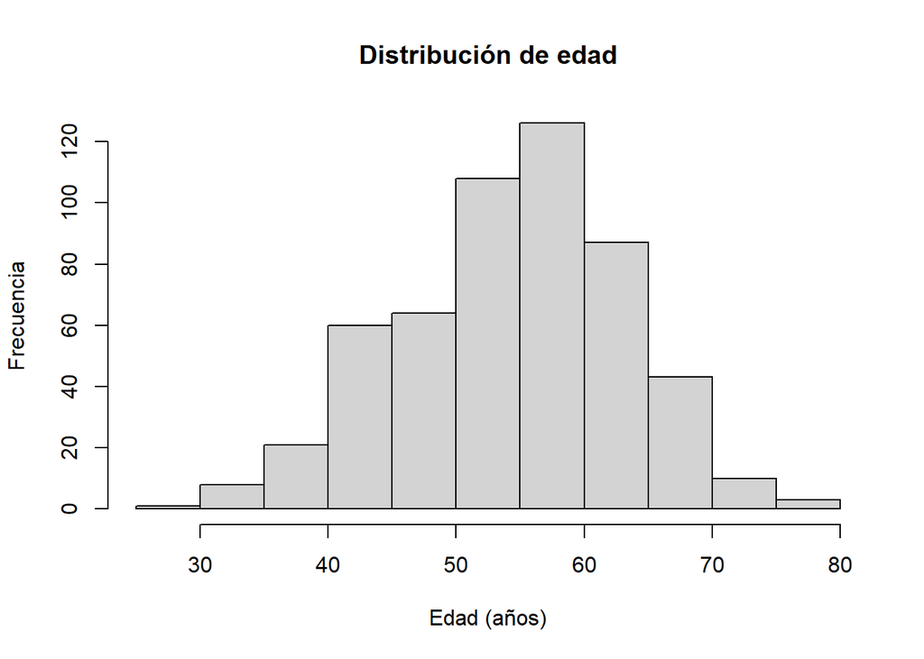

```r
# Distribución de edad
hist(heart_disease_2_clean$age,
     main = "Distribución de edad",
     xlab = "Edad (años)", ylab = "Frecuencia")
```

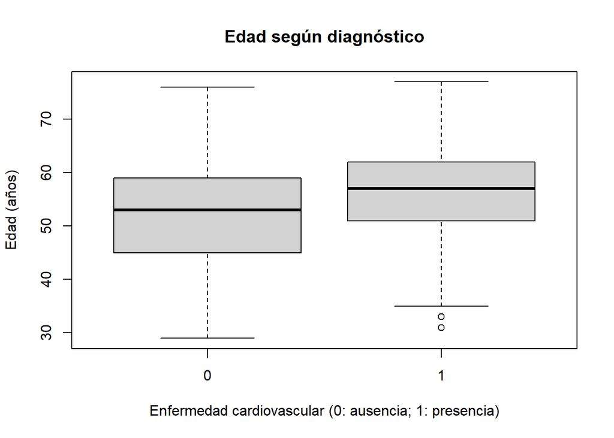

```r
# Comparación variables contínuas según grupo diagnóstico
# Edad
boxplot(age ~ diagnosis_bin, data = heart_disease_2_clean,
     main = "Edad según diagnóstico",
     xlab = "Enfermedad cardiovascular (0: ausencia; 1: presencia)",
     ylab = "Edad (años)")
```

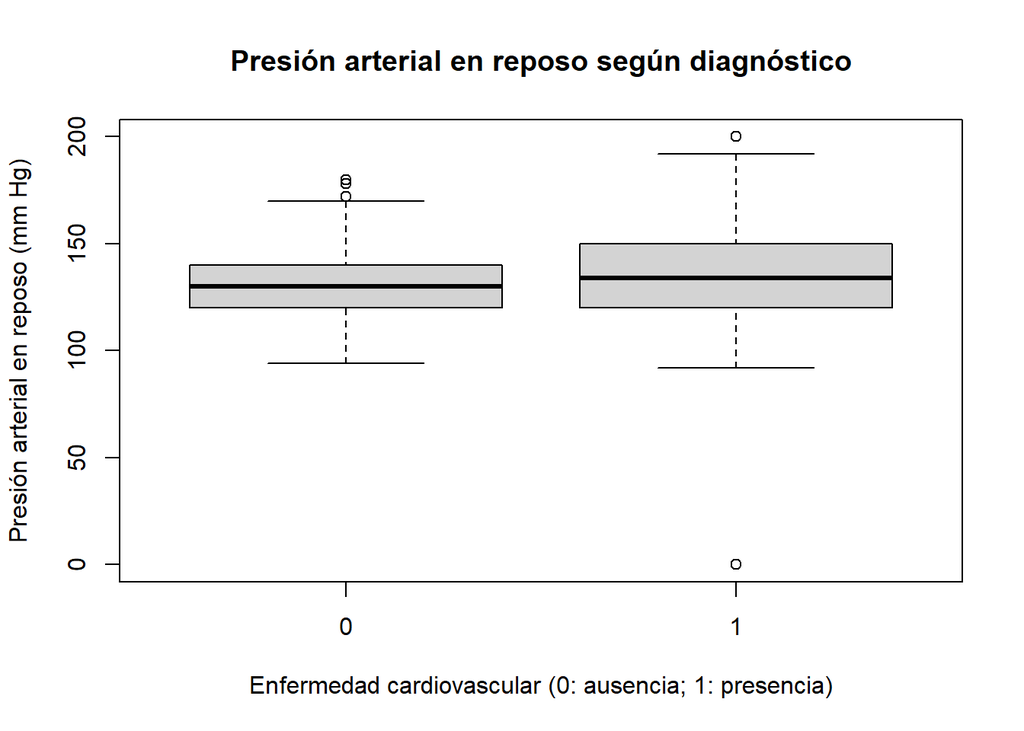

```r
# Presión arterial en reposo
boxplot(trestbps ~ diagnosis_bin, data = heart_disease_2_clean,
     main = "Presión arterial en reposo según diagnóstico",
     xlab = "Enfermedad cardiovascular (0: ausencia; 1: presencia)",
     ylab = "Presión arterial en reposo (mm Hg)")
```

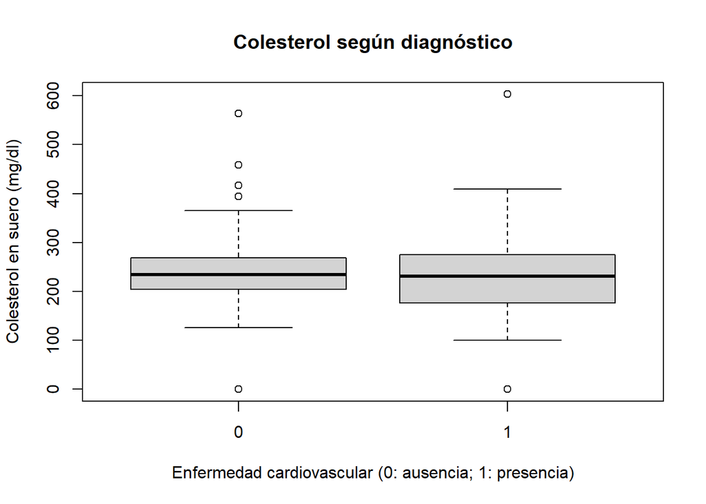

```r
# Colesterol en suero
boxplot(chol ~ diagnosis_bin, data = heart_disease_2_clean,
     main = "Colesterol según diagnóstico",
     xlab = "Enfermedad cardiovascular (0: ausencia; 1: presencia)",
     ylab = "Colesterol en suero (mg/dl)")
```

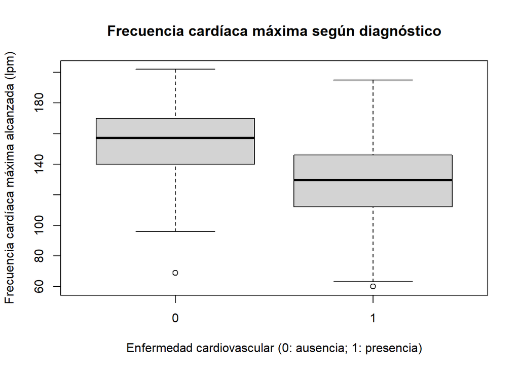

```r
# Frecuencia cardíaca máxima
boxplot(thalch ~ diagnosis_bin, data = heart_disease_2_clean,
     main = "Frecuencia cardíaca máxima según diagnóstico",
     xlab = "Enfermedad cardiovascular (0: ausencia; 1: presencia)",
     ylab = "Frecuencia cardíaca máxima alcanzada (lpm)")
```

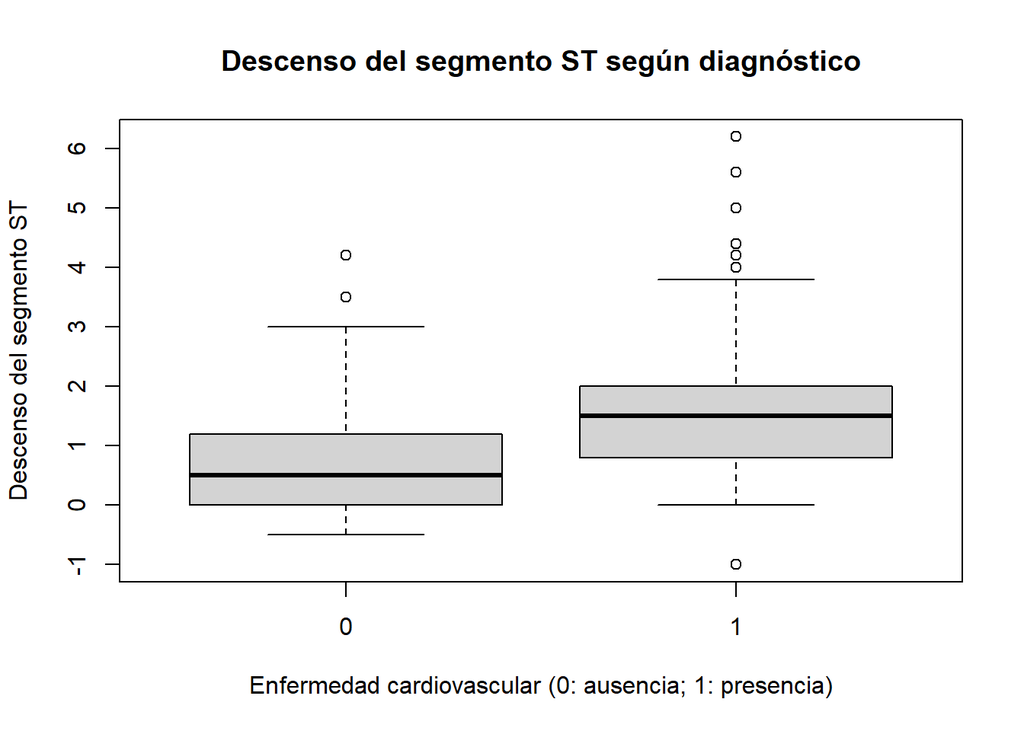

```r
# Descenso del segmento ST
boxplot(oldpeak ~ diagnosis_bin, data = heart_disease_2_clean,
     main = "Descenso del segmento ST según diagnóstico",
     xlab = "Enfermedad cardiovascular (0: ausencia; 1: presencia)",
     ylab = "Descenso del segmento ST")
```

### 3.1.4 Representación gràfica. Variables categóricas

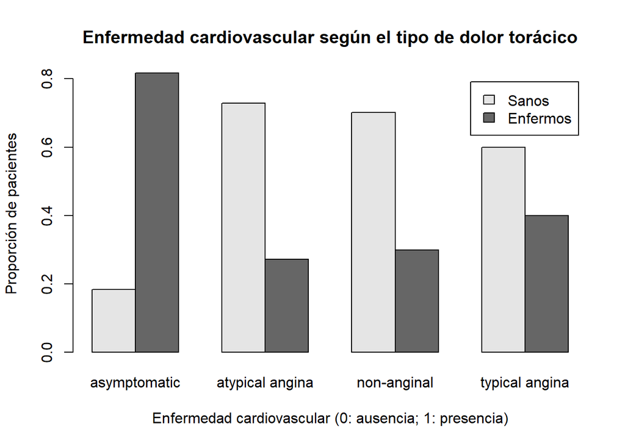

```r
# Tipo de dolor torácico
barplot(
  t(prop.table(
    table(heart_disease_2_clean$cp,
          heart_disease_2_clean$diagnosis_bin), 1)),
  col = c("gray90","gray40"),
  beside = TRUE, legend.text = c("Sanos", "Enfermos"),
  main = "Enfermedad cardiovascular según el tipo de dolor torácico",
  xlab = "Enfermedad cardiovascular (0: ausencia; 1: presencia)",
  ylab = "Proporción de pacientes"
)
```

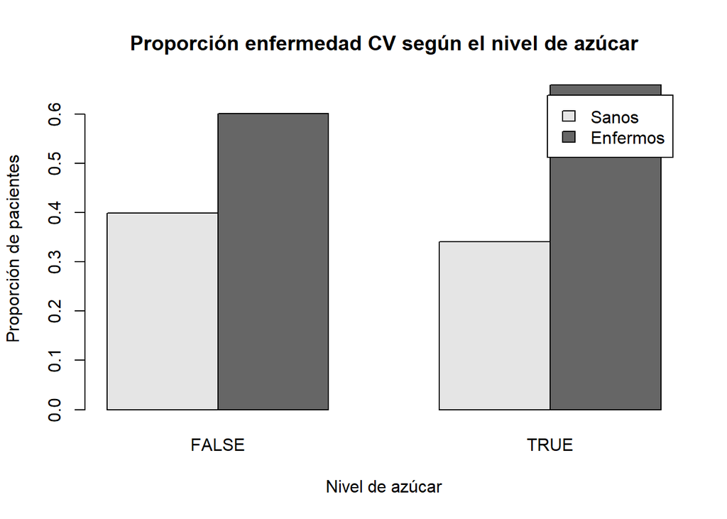

```r
# Nivel de azúcar en sangre en ayunas > 120 mg/dl (Sí/No)
barplot(
  t(prop.table(
    table(heart_disease_2_clean$fbs,
          heart_disease_2_clean$diagnosis_bin), 1)),
  beside = TRUE, legend.text = c("Sanos", "Enfermos"),
  col = c("gray90","gray40"),
  main = "Proporción enfermedad CV según el nivel de azúcar",
  xlab = "Nivel de azúcar",
  ylab = "Proporción de pacientes"
)
```

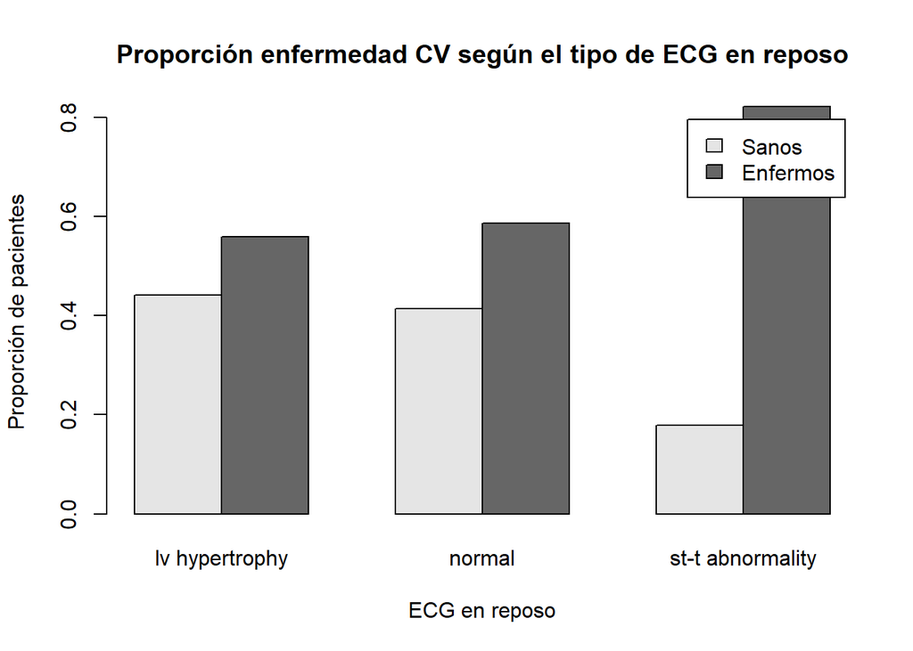

```r
# Resultado del electrocardiograma en reposo
barplot(
  t(prop.table(
    table(heart_disease_2_clean$restecg,
          heart_disease_2_clean$diagnosis_bin), 1)),
  beside = TRUE, legend.text = c("Sanos", "Enfermos"),
  col = c("gray90", "gray40"),
  main = "Proporción enfermedad CV según el tipo de ECG en reposo",
  xlab = "ECG en reposo",
  ylab = "Proporción de pacientes"
)
```

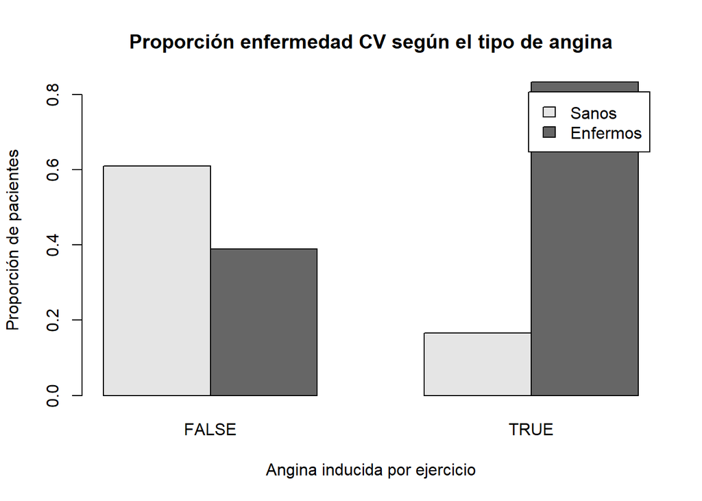

```r
# Angina inducida por ejercicio (Sí/No)
barplot(
  t(prop.table(
    table(heart_disease_2_clean$exang,
          heart_disease_2_clean$diagnosis_bin), 1)),
  beside = TRUE, legend.text = c("Sanos", "Enfermos"),
  col = c("gray90","gray40"),
  main = "Proporción enfermedad CV según el tipo de angina",
  xlab = "Angina inducida por ejercicio",
  ylab = "Proporción de pacientes"
)
```

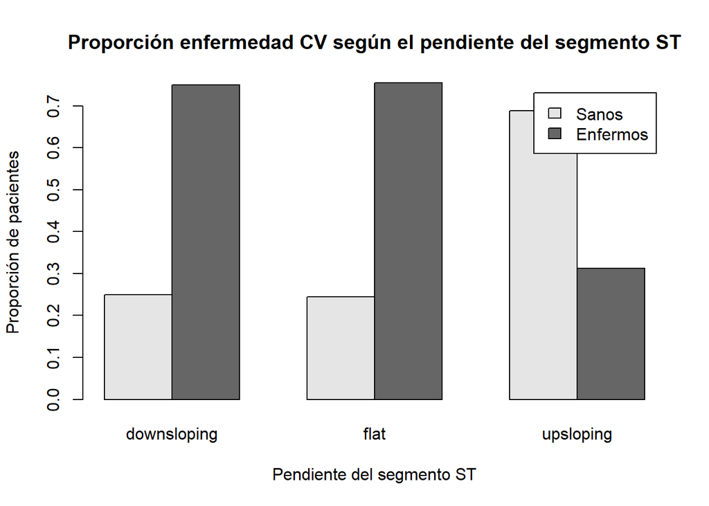

```r
# Pendiente del segmento ST en el ejercicio máximo
barplot(
  t(prop.table(
    table(heart_disease_2_clean$slope,
          heart_disease_2_clean$diagnosis_bin), 1)),
  beside = TRUE, legend.text = c("Sanos", "Enfermos"),
  col = c("gray90","gray40"),
  main = "Proporción enfermedad CV según el pendiente del segmento ST",
  xlab = "Pendiente del segmento ST",
  ylab = "Proporción de pacientes"
)
```

### 3.1.5 Gráfico de correlación por pares

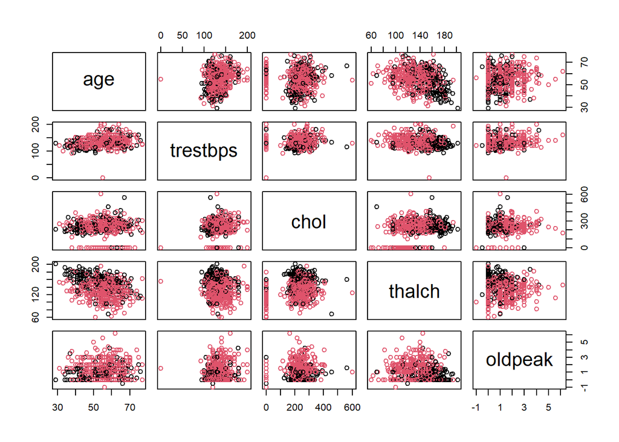

```r
# Correlación por pares. Color según diagnóstico
pairs(
  heart_disease_2_clean[, c("age", "trestbps", "chol", "thalch", "oldpeak")],
  col = heart_disease_2_clean$diagnosis_bin)
```

## 3.2 Ejercicios de inferencia y simulación

1. Basándoos en los conceptos trabajados en el LAB3, definid una función en R que realice algún tipo de cálculo de interés en el contexto del conjunto de datos.

```r
# Función cálculo RR y OR
calculo_riesgo <- function(datos, var_exp, nivel_exp,
                           resultado = "diagnosis_bin") {
  tab <- table(datos[[var_exp]], datos[[resultado]])

  # Id filas
  fila_exp <- which(rownames(tab) == nivel_exp)
  fila_noexp <- which(rownames(tab) != nivel_exp)

  # Riesgos
  riesgo_exp <- tab[fila_exp, "1"] / sum(tab[fila_exp, ])
  riesgo_noexp <- tab[fila_noexp, "1"] / sum(tab[fila_noexp, ])

  # Odds
  odds_exp <- tab[fila_exp, "1"] / tab[fila_exp, "0"]
  odds_noexp <- tab[fila_noexp, "1"] / tab[fila_noexp, "0"]

  list(
    Riesgo_exp = riesgo_exp,
    Riesgo_noexp = riesgo_noexp,
    Diferencia_riesgo = riesgo_exp - riesgo_noexp,
    Riesgo_relativo = riesgo_exp / riesgo_noexp,
    Odds_ratio = odds_exp / odds_noexp
  )
}

calculo_riesgo(heart_disease_2_clean, "sex", "Male")
```

```
## $Riesgo_exp
## [1] 0.7029703
##
## $Riesgo_noexp
## [1] 0.3149606
##
## $Diferencia_riesgo
## [1] 0.3880097
##
## $Riesgo_relativo
## [1] 2.231931
##
## $Odds_ratio
## [1] 5.1475
```

```r
calculo_riesgo(heart_disease_2_clean, "fbs", TRUE)
```

```
## $Riesgo_exp
## [1] 0.6588235
##
## $Riesgo_noexp
## [1] 0.6008969
##
## $Diferencia_riesgo
## [1] 0.05792667
##
## $Riesgo_relativo
## [1] 1.0964
##
## $Odds_ratio
## [1] 1.282553
```

```r
calculo_riesgo(heart_disease_2_clean, "exang", TRUE)
```

```
## $Riesgo_exp
## [1] 0.8333333
##
## $Riesgo_noexp
## [1] 0.3895131
##
## $Diferencia_riesgo
## [1] 0.4438202
##
## $Riesgo_relativo
## [1] 2.139423
##
## $Odds_ratio
## [1] 7.836538
```

2. Basándoos en los conceptos del LAB4 y la PEC2, plantead un mínimo de tres enunciados que respondan a una cuestión de probabilidad.

Los enunciados de probabilidad que planteamos son los siguientes:

- ¿Cuál es la probabilidad de enfermedad cardiovascular en la población?

```r
# Probabilidad de enfermedad cardiovascular en la población
p_enferm <- mean(heart_disease_2_clean$diagnosis_bin == "1")
p_enferm
```

```
## [1] 0.6101695
```

La probabilidad de enfermedad cardiovascular en la población de estudio es 0,61.

- ¿Cuál es la probabilidad de enfermedad cardiovascular en mujeres y en hombres?

```r
# Probabilida de enfermedad cv en mujeres y en hombres
prop.table(table(heart_disease_2_clean$sex,
           heart_disease_2_clean$diagnosis_bin), 1)[, "1"]
```

```
##    Female      Male
## 0.3149606 0.7029703
```

La probabilidad de enfermedad en mujeres es 0,31 y en hombres es 0,70.

- ¿Qué grupo de dolor torácico tiene una probabilidad mayor de enfermedad cardiovascular?

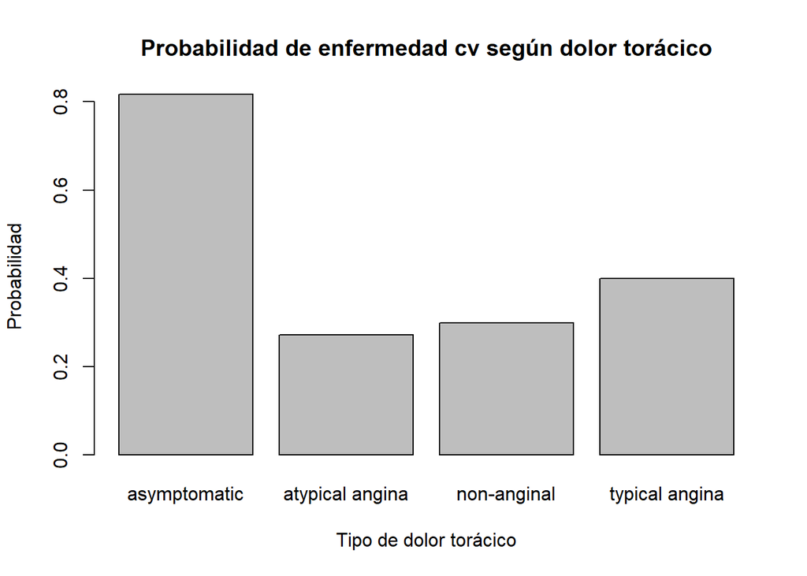

```r
# Realizamos un gráfico de barras a partir de las frecuencias relativas
# de enfermedad cv en los grupos de dolor torácico
barplot(
  prop.table(table(heart_disease_2_clean$cp,
                   heart_disease_2_clean$diagnosis_bin), 1)[, "1"],
  main = "Probabilidad de enfermedad cv según dolor torácico",
  ylab = "Probabilidad",
  xlab = "Tipo de dolor torácico"
)
```

Como se observa en el gráfico de barras, el grupo asintomático tiene la mayor probabilidad de sufrir enfermedad cardiovascular (0,82), seguido del grupo con dolor anginoso (0,40).

- ¿Cuál es la probabilidad de enfermedad cardiovascular si se ha sufrido una angina inducida por el ejercicio? ¿Y si no se ha sufrido angina?

```r
# Probabilidad de enfermedad cv condicional a haber sufrido angina o no
prop.table(table(heart_disease_2_clean$exang,
                 heart_disease_2_clean$diagnosis_bin), 1)[, "1"]
```

```
##     FALSE      TRUE
## 0.3895131 0.8333333
```

La probabilidad de enfermedad cardiovascular si se ha sufrido angina inducida por el ejercicio es 0,83 y si no se ha sufrido es 0,39.

- ¿Existe asociación estadística entre el nivel de azúcar en sangre en ayunas y la enfermedad cardiovascular, o se trata de variables independientes?

```r
# Test de chi cuadrado para determinar si fbs y diagnosis_bin son independientes
tab <- table(heart_disease_2_clean$fbs,
             heart_disease_2_clean$diagnosis_bin)
chisq.test(tab)
```

```
##
##  Pearson's Chi-squared test with Yates' continuity correction
##
## data:  tab
## X-squared = 0.77833, df = 1, p-value = 0.3777
```

```r
# Probabilidades condicionales
prop.table(table(heart_disease_2_clean$fbs,
                 heart_disease_2_clean$diagnosis_bin), 1)[, "1"]
```

```
##     FALSE      TRUE
## 0.6008969 0.6588235
```

```r
# Probabilidad de enfermedad en la población
mean(heart_disease_2_clean$diagnosis_bin == "1")
```

```
## [1] 0.6101695
```

El p-valor (0,3777) es mayor que 0,05 y no podemos rechazar la hipótesis nula. Por lo tanto, en este conjunto de datos, no hay una evidencia estadísticamente significativa de asociación entre el nivel de azúcar en sangre en ayunas y la enfermedad cardiovascular.

La probabilidad condicional de enfermedad en los pacientes con un nivel normal de azúcar (0,60) es prácticamente la misma que la probabilidad de enfermedad en la población (0,61) y es ligeramente superior en los pacientes con un nivel alto (0,65), lo que sugeriria una leve associación. Sin embargo el test de chi al quadrado indica que esta diferencia no es estadísticamente significativa, y sugiere que el nivel de azúcar en sangre en ayunas y la enfermedad cardiovascular son independientes en nuestra muestra. También debemos tener en cuenta que el número de pacientes con un nivel alto de azúcar en sangre es relativamente pequeño (85) y esto limita el poder estadístico.

3. Incluid un mínimo de un enunciado que corresponda a un breve modelo de simulación. Si vuestro conjunto de datos no facilita este tipo de enunciados, podéis generar una o varias distribuciones basándoos en parámetros determinados definidos por vosotros, afines al contexto del estudio.

Si simulamos 10.000 pacientes, ¿cuántos tendran enfermedad cardiovascular?

```r
# Calculamos la probabilidad de enfermedad
p_enferm <- mean(heart_disease_2_clean$diagnosis_bin == "1")

# Simulamos los 10.000 pacientes
set.seed(999)
pac_sim <- rbinom(10000, 1, prob = p_enferm)

# Calculamos cuántos tendran enfermedad cv
mean(pac_sim)
```

```
## [1] 0.6158
```

# 4 Sección 4. Modelos de aprendizaje automático

Basándoos en los conceptos trabajados en el LAB5 y a partir de vuestro conjunto de datos y de los objetivos del estudio, evaluad qué tipo de modelos conviene realizar: aprendizaje supervisado o no supervisado.

- Justificad vuestra elección.
- Mostrad el detalle del estudio realizado.
- Incluid las representaciones gráficas correspondientes (por ejemplo, clústeres, si procede).

Realizaremos un modelo de aprendizaje supervisado, dado que nuestros datos están etiquetados y podemos realizar predicciones específicas dentro de nuestro dataset.

## 4.1 Modelo SVM - clasificación

En primer lugar, realizaremos un modelo de clasificación basado en nuestra variable de clase (*diagnosis*, *diagnosis_bin*) utilizando el algoritmo de máquinas de vectores de soporte (SVM).

1. Usamos la variable *diagnosis_bin* (0/1):

```r
set.seed(123)
library(caTools)
# eliminamos la variable diagnosis de nuestro dataset para que no interfiera
heart_disease_2_clean_1 = heart_disease_2_clean[,-14]
# comprobamos que diagnosis ha sido eliminada
str(heart_disease_2_clean_1)
```

```
## 'data.frame':    531 obs. of  14 variables:
##  $ id           : int  1 2 3 4 5 6 7 8 9 10 ...
##  $ age          : int  63 67 67 37 41 56 62 57 63 53 ...
##  $ sex          : Factor w/ 2 levels "Female","Male": 2 2 2 2 1 2 1 1 2 2 ...
##  $ dataset      : Factor w/ 4 levels "Cleveland","Hungary",..: 1 1 1 1 1 1 1 1 1 1 ...
##  $ cp           : Factor w/ 4 levels "asymptomatic",..: 4 1 1 3 2 2 1 1 1 1 ...
##  $ trestbps     : int  145 160 120 130 130 120 140 120 130 140 ...
##  $ chol         : int  233 286 229 250 204 236 268 354 254 203 ...
##  $ fbs          : Factor w/ 2 levels "FALSE","TRUE": 2 1 1 1 1 1 1 1 1 2 ...
##  $ restecg      : Factor w/ 3 levels "lv hypertrophy",..: 1 1 1 2 1 2 1 2 1 1 ...
##  $ thalch       : int  150 108 129 187 172 178 160 163 147 155 ...
##  $ exang        : Factor w/ 2 levels "FALSE","TRUE": 1 2 2 1 1 1 1 2 1 2 ...
##  $ oldpeak      : num  2.3 1.5 2.6 3.5 1.4 0.8 3.6 0.6 1.4 3.1 ...
##  $ slope        : Factor w/ 3 levels "downsloping",..: 1 2 2 1 3 3 1 3 2 1 ...
##  $ diagnosis_bin: Factor w/ 2 levels "0","1": 1 2 2 1 1 1 2 1 2 2 ...
```

```r
# dividimos nuestro dataset en training y test
split = sample.split(heart_disease_2_clean_1$diagnosis_bin, SplitRatio = 0.7)
heart_disease_train_1 = heart_disease_2_clean_1[split,]
heart_disease_test_1 = heart_disease_2_clean_1[!split,]
head(heart_disease_train_1)
```

```
##   id age    sex   dataset              cp trestbps chol   fbs        restecg
## 1  1  63   Male Cleveland  typical angina      145  233  TRUE lv hypertrophy
## 2  2  67   Male Cleveland    asymptomatic      160  286 FALSE lv hypertrophy
## 3  3  67   Male Cleveland    asymptomatic      120  229 FALSE lv hypertrophy
## 5  5  41 Female Cleveland atypical angina      130  204 FALSE lv hypertrophy
## 7  7  62 Female Cleveland    asymptomatic      140  268 FALSE lv hypertrophy
## 9  9  63   Male Cleveland    asymptomatic      130  254 FALSE lv hypertrophy
##   thalch exang oldpeak       slope diagnosis_bin
## 1    150 FALSE     2.3 downsloping             0
## 2    108  TRUE     1.5        flat             1
## 3    129  TRUE     2.6        flat             1
## 5    172 FALSE     1.4   upsloping             0
## 7    160 FALSE     3.6 downsloping             1
## 9    147 FALSE     1.4        flat             1
```

```r
head(heart_disease_test_1)
```

```
##    id age    sex   dataset              cp trestbps chol   fbs restecg thalch
## 4   4  37   Male Cleveland     non-anginal      130  250 FALSE  normal    187
## 6   6  56   Male Cleveland atypical angina      120  236 FALSE  normal    178
## 8   8  57 Female Cleveland    asymptomatic      120  354 FALSE  normal    163
## 14 14  44   Male Cleveland atypical angina      120  263 FALSE  normal    173
## 18 18  54   Male Cleveland    asymptomatic      140  239 FALSE  normal    160
## 20 20  49   Male Cleveland atypical angina      130  266 FALSE  normal    171
##    exang oldpeak       slope diagnosis_bin
## 4  FALSE     3.5 downsloping             0
## 6  FALSE     0.8   upsloping             0
## 8   TRUE     0.6   upsloping             0
## 14 FALSE     0.0   upsloping             0
## 18 FALSE     1.2   upsloping             0
## 20 FALSE     0.6   upsloping             0
```

```r
# comprobamos que las proporciones de cada categoría se mantienen entre training y test
round(prop.table(table(heart_disease_train_1$diagnosis_bin)*100),1)
```

```
##
##   0   1
## 0.4 0.6
```

```r
round(prop.table(table(heart_disease_test_1$diagnosis_bin)*100),1)
```

```
##
##   0   1
## 0.4 0.6
```

Una vez hemos hecho la división de los conjuntos de training y test, procedemos a entrenar el modelo usando el kernel lineal:

```r
set.seed(123)
library(kernlab)
modelo_1 = ksvm(diagnosis_bin ~ ., data = heart_disease_train_1, kernel = "vanilladot")
modelo_1
```

```
## Support Vector Machine object of class "ksvm"
##
## SV type: C-svc  (classification)
##  parameter : cost C = 1
##
## Linear (vanilla) kernel function.
##
## Number of Support Vectors : 164
##
## Objective Function Value : -150.8809
## Training error : 0.172043
```

Seguidamente, realizamos las predicciones del modelo usando el conjunto de test y lo evaluamos:

```r
# kernel vanilladot - lineal
set.seed(123)
predicciones_1 = predict(modelo_1, heart_disease_test_1)
predicciones_1
```

```
##   [1] 0 0 0 0 0 0 1 0 0 1 0 1 0 1 1 1 0 0 0 0 1 1 0 0 1 1 1 0 1 0 1 1 0 0 1 0 1
##  [38] 1 0 1 1 0 0 0 0 0 0 1 1 1 0 0 1 0 1 0 1 1 1 1 1 0 0 0 1 1 0 1 1 1 0 0 1 0
##  [75] 0 0 0 1 0 0 1 1 0 0 1 0 0 1 0 1 1 1 1 1 1 0 0 0 1 1 1 1 1 1 1 1 1 1 1 1 1
## [112] 1 1 1 1 1 1 1 1 1 1 1 1 1 1 1 1 1 1 1 1 1 1 1 1 1 1 1 1 1 1 1 1 1 1 1 1 1
## [149] 1 1 0 1 1 1 1 1 1 1 1
## Levels: 0 1
```

```r
# tabla de confusión básica
table(predicciones_1, heart_disease_test_1$diagnosis_bin)
```

```
##
## predicciones_1  0  1
##              0 44  9
##              1 18 88
```

```r
# tabla de confusión del paquete caret (usamos como clase positiva 1)
library(caret)
confusionMatrix(predicciones_1, heart_disease_test_1$diagnosis_bin, positive = "1")
```

```
## Confusion Matrix and Statistics
##
##           Reference
## Prediction  0  1
##          0 44  9
##          1 18 88
##
##                Accuracy : 0.8302
##                  95% CI : (0.7626, 0.885)
##     No Information Rate : 0.6101
##     P-Value [Acc > NIR] : 1.487e-09
##
##                   Kappa : 0.6335
##
##  Mcnemar's Test P-Value : 0.1237
##
##             Sensitivity : 0.9072
##             Specificity : 0.7097
##          Pos Pred Value : 0.8302
##          Neg Pred Value : 0.8302
##              Prevalence : 0.6101
##          Detection Rate : 0.5535
##    Detection Prevalence : 0.6667
##       Balanced Accuracy : 0.8084
##
##        'Positive' Class : 1
##
```

El modelo de predicción de la la variable *diagnosis_bin* (0/1) usando el kernel lineal presenta una exactitud del 83%, con una sensibilidad (capacidad de detectar positivos reales (1)) muy alta, situadda en el 90,7%, y una especificidad (capacidad de detectar casos negativos reales (0)) del 71% aproximadamente.

2. Usamos la variable *diagnosis* (0/1/2/3/4):

```r
set.seed(123)
library(kernlab)
# eliminamos la variable diagnosis_bin de nuestro dataset para que no interfiera
heart_disease_2_clean_2 = heart_disease_2_clean[,-15]
# comprobamos que diagnosis_bin ha sido eliminada
str(heart_disease_2_clean_2)
```

```
## 'data.frame':    531 obs. of  14 variables:
##  $ id       : int  1 2 3 4 5 6 7 8 9 10 ...
##  $ age      : int  63 67 67 37 41 56 62 57 63 53 ...
##  $ sex      : Factor w/ 2 levels "Female","Male": 2 2 2 2 1 2 1 1 2 2 ...
##  $ dataset  : Factor w/ 4 levels "Cleveland","Hungary",..: 1 1 1 1 1 1 1 1 1 1 ...
##  $ cp       : Factor w/ 4 levels "asymptomatic",..: 4 1 1 3 2 2 1 1 1 1 ...
##  $ trestbps : int  145 160 120 130 130 120 140 120 130 140 ...
##  $ chol     : int  233 286 229 250 204 236 268 354 254 203 ...
##  $ fbs      : Factor w/ 2 levels "FALSE","TRUE": 2 1 1 1 1 1 1 1 1 2 ...
##  $ restecg  : Factor w/ 3 levels "lv hypertrophy",..: 1 1 1 2 1 2 1 2 1 1 ...
##  $ thalch   : int  150 108 129 187 172 178 160 163 147 155 ...
##  $ exang    : Factor w/ 2 levels "FALSE","TRUE": 1 2 2 1 1 1 1 2 1 2 ...
##  $ oldpeak  : num  2.3 1.5 2.6 3.5 1.4 0.8 3.6 0.6 1.4 3.1 ...
##  $ slope    : Factor w/ 3 levels "downsloping",..: 1 2 2 1 3 3 1 3 2 1 ...
##  $ diagnosis: Ord.factor w/ 5 levels "0"<"1"<"2"<"3"<..: 1 3 2 1 1 1 4 1 3 2 ...
```

```r
# dividimos nuestro dataset en training y test
split = sample.split(heart_disease_2_clean_2$diagnosis, SplitRatio = 0.7)
heart_disease_train_2 = heart_disease_2_clean_2[split,]
heart_disease_test_2 = heart_disease_2_clean_2[!split,]
# veamos el número de casos de cada nivel en los grupo de training y test
table(heart_disease_train_2$diagnosis)
```

```
##
##   0   1   2   3   4
## 145 113  50  50  15
```

```r
table(heart_disease_test_2$diagnosis)
```

```
##
##  0  1  2  3  4
## 62 48 21 21  6
```

```r
# entrenamos el modelo (kernel lineal)
modelo_2 = ksvm(diagnosis ~ ., data = heart_disease_train_2, kernel = "vanilladot")
modelo_2
```

```
## Support Vector Machine object of class "ksvm"
##
## SV type: C-svc  (classification)
##  parameter : cost C = 1
##
## Linear (vanilla) kernel function.
##
## Number of Support Vectors : 262
##
## Objective Function Value : -106.436 -54.0168 -48.3399 -16.9224 -88.1821 -83.5443 -25.7038 -78.8819 -27.6805 -29.3579
## Training error : 0.38874
```

```r
# realizamos las predicciones
predicciones_2 = predict(modelo_2, heart_disease_test_2)
# tabla de confusión
library(caret)
confusionMatrix(predicciones_2, heart_disease_test_2$diagnosis)
```

```
## Confusion Matrix and Statistics
##
##           Reference
## Prediction  0  1  2  3  4
##          0 48 14  2  4  1
##          1 10 26  7  8  2
##          2  2  4  7  5  0
##          3  2  4  5  4  3
##          4  0  0  0  0  0
##
## Overall Statistics
##
##                Accuracy : 0.538
##                  95% CI : (0.457, 0.6175)
##     No Information Rate : 0.3924
##     P-Value [Acc > NIR] : 0.000148
##
##                   Kappa : 0.3366
##
##  Mcnemar's Test P-Value : NA
##
## Statistics by Class:
##
##                      Class: 0 Class: 1 Class: 2 Class: 3 Class: 4
## Sensitivity            0.7742   0.5417   0.3333  0.19048  0.00000
## Specificity            0.7812   0.7545   0.9197  0.89781  1.00000
## Pos Pred Value         0.6957   0.4906   0.3889  0.22222      NaN
## Neg Pred Value         0.8427   0.7905   0.9000  0.87857  0.96203
## Prevalence             0.3924   0.3038   0.1329  0.13291  0.03797
## Detection Rate         0.3038   0.1646   0.0443  0.02532  0.00000
## Detection Prevalence   0.4367   0.3354   0.1139  0.11392  0.00000
## Balanced Accuracy      0.7777   0.6481   0.6265  0.54414  0.50000
```

El kernel que hemos usado para realizar las predicciones anteriores de *diagnosis_bin* y *diagnosis* es lineal (*vanilladot*). Veamos si podemos obtener mejor modelo de predicción usando un kernel más complejo, como por ejemplo el guassiano (*rbfdot*):

1. Usamos la variable *diagnosis_bin* (0/1):

```r
set.seed(123)
library(kernlab)
# entrenamos el modelo
modelo_1_rbf = ksvm(diagnosis_bin ~ ., data = heart_disease_train_1, kernel = "rbfdot")
modelo_1_rbf
```

```
## Support Vector Machine object of class "ksvm"
##
## SV type: C-svc  (classification)
##  parameter : cost C = 1
##
## Gaussian Radial Basis kernel function.
##  Hyperparameter : sigma =  0.0968658458165693
##
## Number of Support Vectors : 210
##
## Objective Function Value : -142.592
## Training error : 0.134409
```

```r
# realizamos las predicciones
predicciones_1_rbf = predict(modelo_1_rbf, heart_disease_test_1)
# tabla de confusión
library(caret)
confusionMatrix(predicciones_1_rbf, heart_disease_test_1$diagnosis_bin, positive = "1")
```

```
## Confusion Matrix and Statistics
##
##           Reference
## Prediction  0  1
##          0 39  9
##          1 23 88
##
##                Accuracy : 0.7987
##                  95% CI : (0.7279, 0.8581)
##     No Information Rate : 0.6101
##     P-Value [Acc > NIR] : 2.715e-07
##
##                   Kappa : 0.559
##
##  Mcnemar's Test P-Value : 0.02156
##
##             Sensitivity : 0.9072
##             Specificity : 0.6290
##          Pos Pred Value : 0.7928
##          Neg Pred Value : 0.8125
##              Prevalence : 0.6101
##          Detection Rate : 0.5535
##    Detection Prevalence : 0.6981
##       Balanced Accuracy : 0.7681
##
##        'Positive' Class : 1
##
```

El modelo de predicción de la la variable *diagnosis_bin* (0/1) usando el kernel gaussiano presenta una exactitud del 80%, con una sensibilidad (capacidad de detectar positivos reales (1)) muy alta, situadda en el 90,7%, y una especificidad (capacidad de detectar casos negativos reales (0)) del 63% aproximadamente.

2. Usamos la variable *diagnosis* (0/1/2/3/4):

```r
set.seed(123)
library(kernlab)
# entrenamos el modelo
modelo_2_rbf = ksvm(diagnosis ~ ., data = heart_disease_train_2, kernel = "rbfdot")
modelo_2_rbf
```

```
## Support Vector Machine object of class "ksvm"
##
## SV type: C-svc  (classification)
##  parameter : cost C = 1
##
## Gaussian Radial Basis kernel function.
##  Hyperparameter : sigma =  0.0944763655393158
##
## Number of Support Vectors : 294
##
## Objective Function Value : -106.8936 -64.8678 -54.9762 -24.0221 -87.6865 -80.1217 -26.4987 -72.6006 -26.5342 -26.7386
## Training error : 0.335121
```

```r
# realizamos las predicciones
predicciones_2_rbf = predict(modelo_2_rbf, heart_disease_test_2)
# tabla de confusión
library(caret)
confusionMatrix(predicciones_2_rbf, heart_disease_test_2$diagnosis)
```

```
## Confusion Matrix and Statistics
##
##           Reference
## Prediction  0  1  2  3  4
##          0 51 14  2  4  1
##          1 10 31 13 12  2
##          2  0  1  0  1  0
##          3  1  2  6  4  3
##          4  0  0  0  0  0
##
## Overall Statistics
##
##                Accuracy : 0.5443
##                  95% CI : (0.4633, 0.6236)
##     No Information Rate : 0.3924
##     P-Value [Acc > NIR] : 7.899e-05
##
##                   Kappa : 0.3252
##
##  Mcnemar's Test P-Value : NA
##
## Statistics by Class:
##
##                      Class: 0 Class: 1 Class: 2 Class: 3 Class: 4
## Sensitivity            0.8226   0.6458  0.00000  0.19048  0.00000
## Specificity            0.7812   0.6636  0.98540  0.91241  1.00000
## Pos Pred Value         0.7083   0.4559  0.00000  0.25000      NaN
## Neg Pred Value         0.8721   0.8111  0.86538  0.88028  0.96203
## Prevalence             0.3924   0.3038  0.13291  0.13291  0.03797
## Detection Rate         0.3228   0.1962  0.00000  0.02532  0.00000
## Detection Prevalence   0.4557   0.4304  0.01266  0.10127  0.00000
## Balanced Accuracy      0.8019   0.6547  0.49270  0.55144  0.50000
```

El modelo de predicción de la la variable *diagnosis* (0/1/2/3/4) usando el kernel gaussiano presenta una exactitud del 54% aproximadamente.

Los resultados de *accuracy* del modelo de predicción en función de la variable predicha y kernel utilizado son:

[output not shown]

Para predecir la variable *diagnosis_bin* de 2 niveles (0/1), el modelo lineal presenta un valor de exactitud más alto que el modelo con el kernel gaussiano. Por otro lado, para predecir la variable *diagnosis* de 5 niveles (0/1/2/3/4), el modelo gaussiano presenta un valor de exactitud ligeramente más alto que el modelo con el kernel lineal.

Para predecir la variable con menor número de niveles (*diagnosis_bin*), el kernel lineal genera una mejor predicción. En cambio, para predecir la variable más compleja (*diagnosis*), el kernel gaussiano genera un mejor modelo.

## 4.2 Regresión lineal múltiple

En segundo lugar, realizaremos una regresión lineal múltiple de una variable numérica de nuestro dataset. En este caso hemos elegido como varible dependiente *thalch*. Nos ha parecido interesante elegir esta variable ya que en el gráfico Frecuencia cardíaca máxima según diagnóstico (3.1.3 Representación gráfica. Variables continuas), se observan diferencias entre los grupos de diagnóstico (0/1).

*thalch* hace referencia a la frecuencia cardíaca máxima. Veamos si ésta viene determinada por alguna/s de las variables de nuestro dataset. Del conjunto de variables que tenemos usaremos sólo algunas. Las variables *id*, *dataset*, *diagnosis* y *diagnosis_bin* son omitidas en este análisis. Mientras que las variables *diagnosis* y *diagnosis_bin* son variables que contienen el resultado y su presencia interferiría en el análisis. Por otro lado, *id* no es una variable de interés y *dataset* no se ha incluído porque no presenta relevancia a nivel clínico y además un 60% de los pacientes son de Cleveland lo que podría introducir alguna asociación no presente.

```r
mrm_thalch = lm(thalch ~ age+sex+cp+trestbps+chol+fbs+restecg+exang+oldpeak+slope, data=heart_disease_2_clean)
summary(mrm_thalch)
```

```
##
## Call:
## lm(formula = thalch ~ age + sex + cp + trestbps + chol + fbs +
##     restecg + exang + oldpeak + slope, data = heart_disease_2_clean)
##
## Residuals:
##     Min      1Q  Median      3Q     Max
## -74.042 -12.089   2.149  14.152  51.740
##
## Coefficients:
##                           Estimate Std. Error t value Pr(>|t|)
## (Intercept)             176.517859   9.420768  18.737  < 2e-16 ***
## age                      -0.753408   0.106351  -7.084 4.61e-12 ***
## sexMale                  -2.311459   2.196383  -1.052 0.293112
## cpatypical angina        11.300281   2.946936   3.835 0.000141 ***
## cpnon-anginal             8.635308   2.429330   3.555 0.000413 ***
## cptypical angina         10.027799   4.050836   2.475 0.013625 *
## trestbps                 -0.016475   0.049286  -0.334 0.738303
## chol                      0.037785   0.009636   3.921 9.99e-05 ***
## fbsTRUE                   2.950190   2.465455   1.197 0.232008
## restecgnormal            -6.461357   2.037763  -3.171 0.001611 **
## restecgst-t abnormality  -6.292761   3.012242  -2.089 0.037191 *
## exangTRUE               -10.258116   2.164869  -4.738 2.79e-06 ***
## oldpeak                   0.913696   0.962486   0.949 0.342908
## slopeflat                -1.959024   3.261610  -0.601 0.548349
## slopeupsloping           13.060008   3.772958   3.461 0.000582 ***
## ---
## Signif. codes:  0 '***' 0.001 '**' 0.01 '*' 0.05 '.' 0.1 ' ' 1
##
## Residual standard error: 20.07 on 516 degrees of freedom
## Multiple R-squared:  0.4123, Adjusted R-squared:  0.3964
## F-statistic: 25.86 on 14 and 516 DF,  p-value: < 2.2e-16
```

Al realizar este análisis observamos que los valores de referencia de cada variable categórica son los siguientes (ya que no aparecen en el resultado):

- sex: female
- cp: asymptomatic
- fbs: false
- restecg: lv hypertrophy
- exang: false
- slope: downsloping

Vamos a modificar los valores de referencias de las variables *restecg* y *slope* a *normal* y *flat*, respectivamente para referenciar respecto a la categoría estándar:

```r
# modificamos los valores de referencia
heart_disease_2_clean$restecg = relevel(heart_disease_2_clean$restecg, ref = "normal")
heart_disease_2_clean$slope = relevel(heart_disease_2_clean$slope, ref = "flat")
# realizamos la regresión lineal múltiple de nuevo
mrm_thalch = lm(thalch ~ age+sex+cp+trestbps+chol+fbs+restecg+exang+oldpeak+slope, data=heart_disease_2_clean)
summary(mrm_thalch)
```

```
##
## Call:
## lm(formula = thalch ~ age + sex + cp + trestbps + chol + fbs +
##     restecg + exang + oldpeak + slope, data = heart_disease_2_clean)
##
## Residuals:
##     Min      1Q  Median      3Q     Max
## -74.042 -12.089   2.149  14.152  51.740
##
## Coefficients:
##                           Estimate Std. Error t value Pr(>|t|)
## (Intercept)             168.097478   8.429462  19.942  < 2e-16 ***
## age                      -0.753408   0.106351  -7.084 4.61e-12 ***
## sexMale                  -2.311459   2.196383  -1.052 0.293112
## cpatypical angina        11.300281   2.946936   3.835 0.000141 ***
## cpnon-anginal             8.635308   2.429330   3.555 0.000413 ***
## cptypical angina         10.027799   4.050836   2.475 0.013625 *
## trestbps                 -0.016475   0.049286  -0.334 0.738303
## chol                      0.037785   0.009636   3.921 9.99e-05 ***
## fbsTRUE                   2.950190   2.465455   1.197 0.232008
## restecglv hypertrophy     6.461357   2.037763   3.171 0.001611 **
## restecgst-t abnormality   0.168595   2.742714   0.061 0.951009
## exangTRUE               -10.258116   2.164869  -4.738 2.79e-06 ***
## oldpeak                   0.913696   0.962486   0.949 0.342908
## slopedownsloping          1.959024   3.261610   0.601 0.548349
## slopeupsloping           15.019032   2.185235   6.873 1.82e-11 ***
## ---
## Signif. codes:  0 '***' 0.001 '**' 0.01 '*' 0.05 '.' 0.1 ' ' 1
##
## Residual standard error: 20.07 on 516 degrees of freedom
## Multiple R-squared:  0.4123, Adjusted R-squared:  0.3964
## F-statistic: 25.86 on 14 and 516 DF,  p-value: < 2.2e-16
```

Obtenemos un valor *Multiple R-squared* de 0.4123, el cual se encuentra por debajo de 0.5, indicando que nuestros predictores no presentan una capacidad de predicción elevada sobre la variable dependiente *thalch*. También relevante es el valor de *p*, que se sitúa en < 2.2e-16, lo que indica significancia.

Las variables y categorías que muestran un efecto estadísticamente significativo sobre la frecuencia cardíaca máxima (*thalch*) son:

| Variable | Categoría |
| --- | --- |
| age | — |
| cp | atypical angina |
| cp | non-anginal |
| cp | typical angina |
| chol | — |
| restecg | lv hypertrophy |
| exang | TRUE |
| slope | upsloping |

Asimismo, entre todos los predictores posibles, vamos a buscar el mejor modelo con los mejores predictores mediante la función *step()*:

```r
step(object = mrm_thalch, direction = "both", trace = 1)
```

```
## Start:  AIC=3200
## thalch ~ age + sex + cp + trestbps + chol + fbs + restecg + exang +
##     oldpeak + slope
##
##            Df Sum of Sq    RSS    AIC
## - trestbps  1      45.0 207908 3198.1
## - oldpeak   1     363.0 208226 3198.9
## - sex       1     446.2 208309 3199.1
## - fbs       1     576.8 208440 3199.5
## <none>                  207863 3200.0
## - restecg   2    4245.0 212108 3206.7
## - chol      1    6194.6 214058 3213.6
## - cp        3    8899.7 216763 3216.3
## - exang     1    9044.8 216908 3220.6
## - slope     2   19029.4 226893 3242.5
## - age       1   20216.4 228080 3247.3
##
## Step:  AIC=3198.12
## thalch ~ age + sex + cp + chol + fbs + restecg + exang + oldpeak +
##     slope
##
##            Df Sum of Sq    RSS    AIC
## - oldpeak   1     345.3 208254 3197.0
## - sex       1     428.4 208337 3197.2
## - fbs       1     549.6 208458 3197.5
## <none>                  207908 3198.1
## + trestbps  1      45.0 207863 3200.0
## - restecg   2    4236.8 212145 3204.8
## - chol      1    6149.8 214058 3211.6
## - cp        3    8868.7 216777 3214.3
## - exang     1    9385.7 217294 3219.6
## - slope     2   19011.2 226920 3240.6
## - age       1   21399.0 229307 3248.1
##
## Step:  AIC=3197
## thalch ~ age + sex + cp + chol + fbs + restecg + exang + slope
##
##            Df Sum of Sq    RSS    AIC
## - sex       1     364.3 208618 3195.9
## - fbs       1     514.6 208768 3196.3
```

[output cut: 26 more lines]

```
## Step:  AIC=3195.05
## thalch ~ age + cp + chol + restecg + exang + slope
##
##            Df Sum of Sq    RSS    AIC
## <none>                  209060 3195.1
## + fbs       1     442.3 208618 3195.9
## + sex       1     291.9 208768 3196.3
## + oldpeak   1     257.8 208802 3196.4
## + trestbps  1       3.8 209056 3197.0
## - restecg   2    4225.3 213285 3201.7
## - cp        3    9108.5 218169 3211.7
## - chol      1    8479.5 217540 3214.2
## - exang     1    9896.6 218957 3217.6
## - slope     2   19219.5 228280 3237.8
## - age       1   20396.4 229457 3242.5
```

```
##
## Call:
## lm(formula = thalch ~ age + cp + chol + restecg + exang + slope,
##     data = heart_disease_2_clean)
##
## Coefficients:
##             (Intercept)                      age        cpatypical angina
##               163.73459                 -0.72964                 11.17008
##           cpnon-anginal         cptypical angina                     chol
##                 8.81548                 10.20620                  0.04195
##   restecglv hypertrophy  restecgst-t abnormality                exangTRUE
##                 6.44830                  0.24628                -10.45056
##        slopedownsloping           slopeupsloping
##                 2.79602                 14.29965
```

El mejor modelo se obtiene con los siguientes predictores y coeficientes:

| Variable | Categoría | Coeficiente |
| --- | --- | --- |
| age | — | -0.72964 |
| cp | atypical angina | 11.17008 |
| cp | non-anginal | 8.81548 |
| cp | typical angina | 10.20620 |
| chol | — | 0.04195 |
| restecg | lv hypertrophy | 6.44830 |
| restecg | st-t abnormality | 0.24628 |
| exang | TRUE | -10.45056 |
| slope | downsloping | 2.79602 |
| slope | upsloping | 14.29965 |

El coeficiente más alto se corresponde a *slope*(Pendiente del segmento ST en el ejercicio máximo) - upsloping. Esto nos indica que la pendiente ascendente se asocia con una mayor frecuencia cardíaca máxima. Por otro lado, el coeficiente más bajo lo encontramos en *exang*(Angina inducida por ejercicio) - true. Esto nos indica que padecer angina inducida por ejercicio se asocia con una menor frecuencia cardíaca máxima, lo cual es coherente ya que estos pacientes no realizan esfuerzos físicos.

## 4.3 ANOVA

Por último, aunque ANOVA no forme parte del ámbito del *machine learning* como tal, nos ha parecido interesante hacer un análisis debido a la presencia de abundantes variables categóricas y numéricas en nuestro dataset.

Vamos a determinar si existen diferencias significativas en la frecuencia cardíaca máxima (*thalch*) entre los grupos de diagnóstico mediante un análisis ANOVA.

Usaremos la variable *diagnosis* para este análisis debido a que presenta 5 grupos (0 - sin enfermedad cardíaca; 1/2/3/4 - grados de enfermedad cardíaca). La variable *diagnosis_bin* solamente tiene 2 grupos (0/1) y no es necesario realizar una ANOVA, con t-test sería suficiente.

En primer lugar realizaremos un test de normalidad para determinar si la distribución de *thalch* en cada grupo de diagnosis es normal o no:

```r
# número de casos por nivel de diagnóstico
table(heart_disease_2_clean$diagnosis)
```

```
##
##   0   1   2   3   4
## 207 161  71  71  21
```

Vemos que en la matyoría de grupos, el número de casos es superior a 50, por tanto el test de normalidad que realizaremos es Kolmogorov-Smirnov:

```r
library(nortest)
# evaluamos normalidad mediante test Kolmogorov-Smirnov
by(data = heart_disease_2_clean, INDICES = heart_disease_2_clean$diagnosis, FUN = function(x){lillie.test(x$thalch)})
```

```
## heart_disease_2_clean$diagnosis: 0
##
##  Lilliefors (Kolmogorov-Smirnov) normality test
##
## data:  x$thalch
## D = 0.092662, p-value = 0.0001817
##
## ------------------------------------------------------------
## heart_disease_2_clean$diagnosis: 1
##
##  Lilliefors (Kolmogorov-Smirnov) normality test
##
## data:  x$thalch
## D = 0.068189, p-value = 0.06477
##
## ------------------------------------------------------------
## heart_disease_2_clean$diagnosis: 2
##
##  Lilliefors (Kolmogorov-Smirnov) normality test
##
## data:  x$thalch
## D = 0.12304, p-value = 0.009565
##
## ------------------------------------------------------------
## heart_disease_2_clean$diagnosis: 3
##
##  Lilliefors (Kolmogorov-Smirnov) normality test
##
## data:  x$thalch
## D = 0.066076, p-value = 0.6204
##
## ------------------------------------------------------------
## heart_disease_2_clean$diagnosis: 4
##
##  Lilliefors (Kolmogorov-Smirnov) normality test
##
## data:  x$thalch
## D = 0.10609, p-value = 0.7771
```

Observamos que el test de normalidad muestra falta de normalidad en los grupos 0 y 2, pero no en el resto. El siguiente paso es evaluar la varianza constante entre los grupos (homocedasticidad). Aplicaremos el test de Fligner-Killeen para ello.

```r
# evaluamos homocedasticidad
fligner.test(thalch ~ diagnosis, heart_disease_2_clean)
```

```
##
##  Fligner-Killeen test of homogeneity of variances
##
## data:  thalch by diagnosis
## Fligner-Killeen:med chi-squared = 1.6755, df = 4, p-value = 0.7952
```

El *p* valor se sitúa en 0.7952, lo que indica que la varianza es constante entre los grupos de *diagnosis*. A pesar que hay dos grupos que muestran falta de normalidad, continuaremos con el análisis ANOVA para obtener información debido a que la mayoría de grupos muestran normalidad y se cumple la homocedasticidad entre grupos.

```r
resultado_anova = aov(thalch ~ diagnosis, data = heart_disease_2_clean)
summary (resultado_anova)
```

```
##              Df Sum Sq Mean Sq F value Pr(>F)
## diagnosis     4  71404   17851   33.26 <2e-16 ***
## Residuals   526 282306     537
## ---
## Signif. codes:  0 '***' 0.001 '**' 0.01 '*' 0.05 '.' 0.1 ' ' 1
```

Vemos que el valor de *p* es <2e-16, lo que indica que la variable *diagnosis* tiene un efecto estadísticamente significativo sobre la frecuencia cardíaca máxima. Veamos entre qué grupos de *diagnosis* existen estas diferencias. Para ello realizaremos un test de significancia Tukey:

```r
TukeyHSD(resultado_anova)
```

```
##   Tukey multiple comparisons of means
##     95% family-wise confidence level
##
## Fit: aov(formula = thalch ~ diagnosis, data = heart_disease_2_clean)
##
## $diagnosis
##             diff        lwr        upr     p adj
## 1-0 -21.86404417 -28.527654 -15.200434 0.0000000
## 2-0 -22.70211608 -31.423629 -13.980604 0.0000000
## 3-0 -28.16690481 -36.888417 -19.445392 0.0000000
## 4-0 -21.85369220 -36.376693  -7.330692 0.0004238
## 2-1  -0.83807191  -9.872187   8.196044 0.9990826
## 3-1  -6.30286064 -15.336976   2.731255 0.3133576
## 4-1   0.01035197 -14.702500  14.723204 1.0000000
## 3-2  -5.46478873 -16.107924   5.178346 0.6244081
## 4-2   0.84842388 -14.903690  16.600538 0.9998936
## 4-3   6.31321261  -9.438901  22.065327 0.8080657
```

Las diferencias significativas las encontramos entre el grupo 0 (sin enfermedad cardíaca) y el resto de grupos (1/2/3/4). Realizamos un gráfico de cajas de la frecuencia cardíaca máxima en función del grupo de diagnóstico, acompañada de una tabla con las medias de cada grupo para visualizar estas diferencias:

```r
# tabla de medias
aggregate(thalch ~ diagnosis, data = heart_disease_2_clean, FUN = mean)
```

```
##   diagnosis   thalch
## 1         0 152.7585
## 2         1 130.8944
## 3         2 130.0563
## 4         3 124.5915
## 5         4 130.9048
```

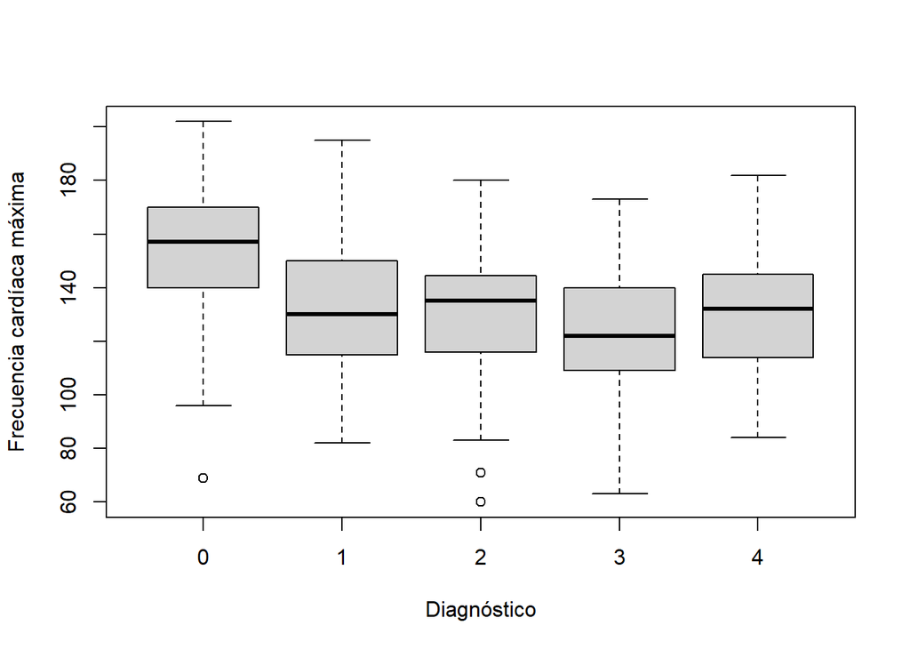

```r
# gráfico boxplot
boxplot(thalch ~ diagnosis, data = heart_disease_2_clean, id.method = "y", ylab = "Frecuencia cardíaca máxima", xlab = "Diagnóstico")
```

# 5 Sección 5. Visualización

Utilizando la herramienta Shiny (basada en los conceptos trabajados en el LAB6), realizad una propuesta de visualización de datos del conjunto de datos trabajado, a partir de unos determinados criterios a vuestra elección.

```r
library(shiny)
library(shinythemes)
library(DT)
```

```r
# Definimos la interfície de usuario
ui <- fluidPage(
  theme = shinytheme("flatly"),

  titlePanel("Visualización de dataset"),

  sidebarLayout(
    sidebarPanel(
      fileInput(
        "file",
        "Carga del archivo (CSV/TSV/TXT)",
        accept = c(".csv", ".tsv", ".txt")
      ),

      selectInput(
        "sep",
        "Separador",
        choices = c("Coma" = ",", "Punto y coma" = ";", "Tabulador" = "\t"),
        selected = ","
      ),

      selectInput(
        "dec",
        "Decimal",
        choices = c("Coma" = ",", "Punto" = "."),
        selected = "."
      ),

      numericInput(
        "skip",
        "Número de linias a saltar",
        value = 0,
        min = 0
      ),

      # Transformaciones del dataset
      checkboxInput(
        "rm_na",
        "Eliminar filas con NA",
        value = TRUE
      ),

      checkboxInput(
        "chr_to_factor",
        "Convertir variables categóricas (chr) a factor",
        value = TRUE
      ),

      checkboxInput(
        "logi_to_factor",
        "Convertir variables lógicas (logi) a factor",
        value = TRUE
      ),

      # Selector de variables
      selectInput(
        "num_var",
        "Variable numérica:",
        choices = NULL
      ),

      selectInput(
        "fac_var",
        "Variable categórica:",
        choices = NULL
      ),
    ),

    mainPanel(
      tabsetPanel(
        tabPanel(
          "Datos",
          h4("Vista previa"),
          DTOutput("table")
        ),
        tabPanel(
          "Resultados",
          h4("Resumen estadístico"),
          tableOutput("stats")
        ),
        tabPanel(
          "Gráficos",
          h4("Gráfico"),
          plotOutput("plot")
        )
      )
    )
  )
)

server <- function(input, output, session) {
  # Cargamos los datos crudos
  raw_data <- reactive({
    req(input$file)
    read.table(
      input$file$datapath,
      header = TRUE,
      sep = input$sep,
      dec = input$dec,
      skip = input$skip,
      stringsAsFactors = FALSE
    )
  })

  # Transformaciones si aplican
  data <- reactive({
    df <- raw_data()

    if (input$rm_na) {
      df <- na.omit(df)
    }

    if (input$chr_to_factor) {
      df[] <- lapply(df, function(x) {
        if (is.character(x)) {
          factor (x)
        } else {x}
      })
    }

    if (input$logi_to_factor) {
      df[] <- lapply(df, function(x) {
        if (is.logical(x)) {
          factor (x, labels = c("No", "Sí"))
        } else {x}
      })
    }
    df
  })

  # Selectores de variables numéricas y categóricas
  observeEvent(data(), {
    df <- data()

    num_vars <- names(df)[sapply(df, is.numeric)]
    fac_vars <- names(df)[sapply(df, is.factor)]

    updateSelectInput(session, "num_var", choices = num_vars)
    updateSelectInput(session, "fac_var", choices = fac_vars)
  })

  # Vista previa de los datos
  output$table <- renderDT({
    req(data())
    datatable(
      head(data(), 10)
    )
  })

  # Resúmen estadístico
  output$stats <- renderPrint({
    req(data(), input$num_var, input$fac_var)

    tapply(
      data()[[input$num_var]],
      data()[[input$fac_var]],
      summary
    )
  })

  # Diagrama de caja
  output$plot <- renderPlot({
    req(input$num_var, input$fac_var)

    boxplot(
      data()[[input$num_var]] ~ data()[[input$fac_var]],
      xlab = input$fac_var,
      ylab = input$num_var,
      col = "lightblue",
      main = "Diagrama de caja"
    )
  })
}

shinyApp(ui = ui, server = server)
```

Shiny applications not supported in static R Markdown documents

Adjuntamos aquí 3 capturas de imagen de la aplicación Shiny:

[figure not shown]

# 6 Sección 6. Conclusiones

A partir de todo el estudio realizado en esta práctica, realizad una valoración final. Para ello, podéis basaros en preguntas como:

- ¿Disponemos de conclusiones finales?
- ¿Sería necesario realizar un análisis más avanzado?
- ¿Faltan datos para obtener otro tipo de información como…?
- ¿Se puede utilizar alguna de las conclusiones para tomar algún tipo de decisiones?

En otro orden de cuestiones, valorad también el trabajo en grupo y la calidad del informe de análisis de datos generado.

## 6.1 Conclusiones

### 6.1.1 Análisis descriptivo

En el análisis descriptivo observamos que, en promedio, los individuos con enfermedad cardíaca son ligeramente mayores. Esto estaría en consonancia con el hecho que el riesgo de padecer enfermedad cardíaca aumenta con la edad. No obstante esta diferencia es moderada.

El grupo con enfermedad presenta mayor presión arterial en reposo, con mayor variabilidad, lo que sugiere que la hipertensión podría estar asociada a la enfermedad, aunque la diferencia no es demasiado grande. Contrariamente a lo que esperaríamos vemos que los niveles de colesterol en suero (mg/dl) son mayores en promedio en el grupo con ausencia de enfermedad que en el grupo con enfermedad. No obstante, también se observa una alta variabilidad en este grupo. Los menores niveles de colesterol en el grupo con enfermedad podrían ser debidos al control farmacológico con estatinas en estos pacientes. De algún modo, este resultado podría indicar que el parámetro colesterol total de forma aislada no necesariamente discrimina bien entre pacientes con o sin enfermedad cardíaca y que, por ello, se deberían tener en cuenta otros factores (colesterol LDL versus HDL, triglicéridos, entre otros).

Durante el ejercicio observamos que los pacientes con enfermedad cardíaca alcanzan una **frecuencia cardíaca máxima** menor. Esta es **una de las diferencias más acusadas entre grupos**. Este resultado podría estar relacionado con una menor capacidad funcional del miocardio debido a la enfermedad cardíaca, a un efecto de la isquemia, o bien a la posible terapia con betabloqueantes, en estos pacientes, que también disminuye la frecuencia cardíaca. Finalmente se detecta un mayor descenso del ST inducido por el ejercicio en el grupo con enfermedad, lo que podría indicar una mayor afectación coronaria i/o una mayor isquemia inducida por el ejercicio.

En global los pacientes con enfermedad cardíaca son ligeramente mayores, presentan mayor presión arterial, alcanzan una menor frecuencia cardíaca máxima y muestran mayor depresión del segmento ST durante el ejercicio. El segmento ST es la parte del electrocardiograma que refleja la repolarización ventricular. Cuando durante un esfuerzo el corazón no recibe suficiente oxígeno (isquemia) aparece depresión del segmento ST inducida por el ejercicio. La existencia de diferencias o no en estas variables y la presencia de valores atípicos se puede visualizar en la representación que hemos realizado con diagramas de cajas.

La muestra está claramente dominada por hombres (el 76%), lo que determinará que los análisis y modelos derivados podrían estar sesgados y las conclusiones que se extraerían del estudio de estos datos podrían no ser generalizables a las mujeres. La mayoría de individuos no presentan niveles elevados de azúcar en sangre en ayunas, aunque este podría ser un factor de riesgo relevante en el 16% que sí que los presentan. Más de la mitad de la población de estudio presenta un ECG en reposo normal, incluso en pacientes con enfermedad cardíaca, lo que pone de manifiesto la importancia de las pruebas de esfuerzo para un mejor diagnóstico electrofisiológico de la enfermedad.

En el gráfico de enfermedad CV según el tipo de dolor torácico, vemos que muchos pacientes no presentan dolor torácico (son asintomáticos). De ello se derivaría que la ausencia de dolor no implica ausencia de enfermedad. En el gráfico de enfermedad CV según el nivel de azúcar vemos una mayor proporción de individuos enfermos en el grupo de individuos con niveles de azúcar mayores, lo que sugeriría que la hiperglicemia en ayunas se asocia con un mayor riesgo de enfermedad cardiovascular. No obstante, esta asociación es moderada en el dataset por el bajo porcentaje de individuos con este factor. En el gráfico de enfermedad según ECG en reposo volvemos a ver que un ECG normal no descarta la presencia de enfermedad CV. Por otro lado se detecta una proporción muy alta de pacientes enfermos en el grupo con alteraciones ST-T en reposo. Aunque por si solas estas alteraciones no son diagnósticas, sí que son hallazgos muy frecuentes y pueden ser indicativas de afección cardíaca. En el gráfico de enfermedad CV según la presencia o no de angina inducida por el ejercicio observamos una proporción muy alta de enfermos en el grupo con angina, lo que indicaría que la aparición de angina durante el ejercicio es un signo claro de enfermedad cardíaca. Finalmente, en el gráfico de la proporción de enfermedad según el pendiente del segmento ST vemos un claro predominio de enfermos en los grupos *downsloping* y *flat*; estos dos patrones se relacionan con una mayor probabilidad de isquemia cardíaca y con sospecha de isquemia, respectivamente.

### 6.1.2 Modelos de aprendizaje automático y ANOVA

Los análisis de *machine learning* realizados permiten concluir que la predicción de la variable de clase (*diagnosis*) en formato binario se realiza con una exactitud elevada mediante el modelo SVM, en comparación con la predicción de la misma variable de cinco niveles. Esto sugiere que la simplificación de la variable a predecir se traduce en una mejora de la capacidad predictiva del modelo. Alternativamente, podemos plantearnos la posibilidad de utilizar otros algoritmos de clasificación, como *Naive Bayes*, *Decision trees* o *Random forest*, con el objetivo de evaluar si estos métodos permiten mejorar la predicción de la variable de clase. Esta comparación se realizaría evaluando métricas como *accuracy*, sensibilidad y especificidad.

Por otro lado, la regresión lineal múltiple ha permitido determinar qué variables de nuestro dataset presentan un efecto estadísticamente significativo sobre la frecuencia cardíaca máxima, utilizada como variable dependiente numérica. No obstante, para estudiar el efecto de las variables clínicas sobre la variable de clase factor (*diagnosis*), podríamos haber usado un modelo de regresión logística y sería interesante como siguiente paso en el estudio.

Por último, mediante el análisis ANOVA se ha podido estudiar con mayor detalle el efecto de variables categóricas con tres o más niveles sobre variables numéricas. En concreto, se ha observado que el grupo de diagnóstico presenta un efecto estadísticamente significativo sobre la frecuencia cardíaca máxima. Este tipo de análisis se podría realizar sobre otras variables de nuestro dataset para profundizar en la relación entre el resto de factores clínicos y variables numéricas.

### 6.1.3 Limitaciones del dataset y valoración final

Por otra parte, se ha echado en falta la presencia de variables demográficas y de estilo de vida en nuestro dataset. Variables como el hábito de fumar, el consumo de alcohol, el peso corporal o el índice de masa corporal habrían aportado un valor añadido al dataset y posterior análisis, permitiendo evaluar la influencia de estos factores sobre la presencia de enfermedad cardíaca. Este tipo de análisis habría facilitado, además, la posterior toma de decisiones relacionadas con la prevención y un estilo de vida saludables.